# An acoustic analysis of vowel production by L1-Chinese learners of English

Martin Schweinberger

2024-11-13

# Preparation

install packages

```r
# install
install.packages("tidyverse")
install.packages("here")
install.packages("adehabitatHR")
install.packages("lme4")
install.packages("sjPlot")
install.packages("report")
install.packages("flextable")
install.packages("cowplot")
install.packages("randomForest")
install.packages("rms")
install.packages("caret")
install.packages("Hmisc")
install.packages("glmulti")
install.packages("partykit")
install.packages("ggparty")
install.packages("hunspell")
install.packages("janitor")
install.packages("glmmTMB")
install.packages("quanteda")
install.packages("viridis")
install.packages("MuMIn")
install.packages('TMB', type = 'source')
```

load packages

```r
library(tidyverse)
library(here)
library(adehabitatHR)
library(lme4)
library(sjPlot)
library(report)
library(flextable)
library(cowplot)
library(randomForest)
library(rms)
library(caret)
library(Hmisc)
library(quanteda)
#library(glmulti)
library(partykit)
library(ggparty)
library(hunspell)
library(janitor)
library(viridis)
library(TMB)
library(MuMIn)
# set options
options(stringsAsFactors = F)
options(scipen = 999)
options(max.print=10000)
```

# Load data

```r
# load .rda data
cdat  <- base::readRDS(file = here::here("data", "cleandat.rda")) %>%
  dplyr::filter(vowel != "ʌ") %>%
  dplyr::ungroup() %>%
  dplyr::relocate(duration, .after = F2) %>%
  dplyr::relocate(file, .after = Age)
# inspect
str(cdat); head(cdat)
```

```
## tibble [7,616 × 26] (S3: tbl_df/tbl/data.frame)
##  $ id      : chr [1:7616] "4" "4" "8" "4" ...
##  $ label   : chr [1:7616] "{" "u:" "I" "u:" ...
##  $ word    : chr [1:7616] "that" "to" "with" "to" ...
##  $ F1      : num [1:7616] 714 571 439 459 479 ...
##  $ F2      : num [1:7616] 1357 1339 1234 682 996 ...
##  $ duration: num [1:7616] 0.21 0.08 0.11 0.09 0.06 ...
##  $ speaker : chr [1:7616] "CHN001" "CHN001" "CHN001" "CHN001" ...
##  $ vowel   : chr [1:7616] "æ" "u" "ɪ" "u" ...
##  $ type    : chr [1:7616] "CHN" "CHN" "CHN" "CHN" ...
##  $ gender  : chr [1:7616] "male" "male" "male" "male" ...
##  $ Age     : int [1:7616] 20 20 20 20 20 20 20 19 19 20 ...
##  $ file    : chr [1:7616] "SM_CHN_PTJ1_001_B1_1" "SM_CHN_PTJ1_001_B1_1" "SM_CHN_PTJ1_001_B1_1" "SM_CHN_PTJ1_001_B1_1" ...
##  $ tvariety: chr [1:7616] "us" "us" "us" "us" ...
##  $ edist   : num [1:7616] 399 250 792 715 1033 ...
##  $ barkF1  : num [1:7616] 6.63 5.52 4.38 4.56 4.73 ...
##  $ barkF2  : num [1:7616] 10.44 10.35 9.83 6.39 8.5 ...
##  $ fspeaker: chr [1:7616] "CHN001" "CHN001" "CHN001" "CHN001" ...
##  $ lobF1   : num [1:7616, 1] 1.22 0.0871 -0.9672 -0.8061 -0.6498 ...
##  $ lobF2   : num [1:7616, 1] -0.298 -0.345 -0.617 -2.056 -1.239 ...
##  $ normF1  : num [1:7616] 714 571 439 459 479 ...
##  $ normF2  : num [1:7616] 1357 1339 1234 682 996 ...
##  $ cF1     : num [1:7616] 5.96 4.2 5.04 4.2 5.04 ...
##  $ cF2     : num [1:7616] 10.8 10.8 11.5 10.8 11.5 ...
##  $ ED      : num [1:7616] 0.739 1.379 1.78 4.381 2.994 ...
##  $ WordType: chr [1:7616] "grammatical" "lexical" "grammatical" "lexical" ...
##  $ prof    : Factor w/ 3 levels "A2","B1","B2": 2 2 2 2 2 2 2 2 2 2 ...
```

```
## # A tibble: 6 × 26
##   id    label word     F1    F2 duration speaker vowel type  gender   Age file
##   <chr> <chr> <chr> <dbl> <dbl>    <dbl> <chr>   <chr> <chr> <chr>  <int> <chr>
## 1 4     {     that   714. 1357.   0.210  CHN001  æ     CHN   male      20 SM_CH…
## 2 4     u:    to     571. 1339.   0.0800 CHN001  u     CHN   male      20 SM_CH…
## 3 8     I     with   439  1234.   0.110  CHN001  ɪ     CHN   male      20 SM_CH…
## 4 4     u:    to     459.  682    0.0900 CHN001  u     CHN   male      20 SM_CH…
## 5 4     I     with   479.  996.   0.0600 CHN001  ɪ     CHN   male      20 SM_CH…
## 6 8     u:    do     508. 1238.   0.0600 CHN001  u     CHN   male      20 SM_CH…
## # ℹ 14 more variables: tvariety <chr>, edist <dbl>, barkF1 <dbl>, barkF2 <dbl>,
## #   fspeaker <chr>, lobF1 <dbl[,1]>, lobF2 <dbl[,1]>, normF1 <dbl>,
## #   normF2 <dbl>, cF1 <dbl>, cF2 <dbl>, ED <dbl>, WordType <chr>, prof <fct>
```

```r
table(cdat$vowel, cdat$word)
```

```
##
##      bad   be best  big  bit book books boost  dad dead death debt debts depth
##   æ  235    0    0    0    0    0     0     0    1    0     0    0     0     0
##   ɛ    0    0   20    0    0    0     0     0    0    2     3   28     2     1
##   i    0  787    0    1    0    0     0     0    0    0     0    0     0     0
##   ɪ    0   91    0   19   14    0     0     0    0    0     0    0     0     0
##   u    0    0    0    0    0    0     0     1    0    0     0    0     0     0
##   ʊ    0    0    0    0    0    7    14     0    0    0     0    0     0     0
##
##      did   do  gap  gas  get gets good guess  had  has   he head  his  hit keep
##   æ    0    0    1    3    0    0    0     0   22   94    0    0    0    0    0
##   ɛ    0    0    0    0  227    7    0    21    8   11    0    1    0    0    0
##   i    0    0    0    0    0    0    0     0    0    0   73    0    0    0   39
##   ɪ   12    0    0    0    0    0    0     0    0    0    7    0   50    1    0
##   u    0  274    0    0    0    0    0     0    0    0    0    0    0    0    0
##   ʊ    0    0    0    0    0    0  306     0    0    0    0    0    0    0    0
##
##     kept  key kids pass past  pat path peak push  put  sad said  sat says seat
##   æ    0    0    0    2    4    1    1    0    0    0    1    0    2    0    0
##   ɛ    1    0    0    0    0    0    0    0    0    0    0   32    0    7    0
##   i    0    1    0    0    0    0    0    1    0    0    0    0    0    0    2
##   ɪ    0    0    5    0    0    0    0    0    0    0    0    0    0    0    0
##   u    0    0    0    0    0    0    0    0    0    0    0    0    0    0    0
##   ʊ    0    0    0    0    0    0    0    0    1   22    0    0    0    0    0
##
##     seats  see seep sees  set sets  she shes shits shoes  sit speak step suit
##   æ     0    0    0    0    0    0    0    0     0     0    0     0    0    0
##   ɛ     0    0    0    0    5    2    0    0     0     0    0     0   14    0
##   i     3   37    1    1    0    0   20    2     0     0    0     2    0    0
##   ɪ     0    0    0    0    0    0    6    0     2     0   15     0    0    0
##   u     0    0    0    0    0    0    0    0     0     2    0     0    0    1
##   ʊ     0    0    0    0    0    0    0    0     0     0    0     0    0    0
##
##     task teeth test that thats this   to  too took  two   we weak week well
##   æ    5     0    0 1076    97    0    0    0    0    0    0    0    0    0
##   ɛ    0     0    1  209     0    0    0    0    0    0    0    0    0    1
##   i    0     2    0    0     0    0    9    2    0    0  519    5    2    0
##   ɪ    0     0    0    0     0  359    0    0    0    0  192    0    0    0
##   u    0     0    0    0     0    0 1723   44    0   26    0    0    0    0
##   ʊ    0     0    0    0     0    0    3    0    6    0    0    0    0    0
##
##      who whos wish with
##   æ    0    0    0    0
##   ɛ    0    0    0    0
##   i    0    0    0    0
##   ɪ    0    0    7  526
##   u  222    1    0    0
##   ʊ    0    0    0    0
```

# Reduce data

```r
bdat <- cdat %>%
  dplyr::mutate(label = stringr::str_remove_all(label, ":"),
                gender = ifelse(gender == "f", "female", gender),
                gender = ifelse(gender == "m", "male", gender),
                tvariety = ifelse(tvariety == "us", "AmE", tvariety),
                tvariety = ifelse(tvariety == "gb", "BrE", tvariety)) %>%
  droplevels(.)  %>%
  dplyr::rename(Vowel = label,
                Word = word,
                TargetVariety = tvariety,
                Gender = gender,
                Duration = duration,
                Proficiency = prof,
                Speaker = speaker) %>%
  # clean word
  dplyr::mutate(Word = str_remove_all(Word, "\\W")) %>%
  dplyr::filter(hunspell_check(Word) == T) %>%
  # remove "shits"
  dplyr::filter(Word != "shits",
                Word != "stat",
                Word != "whats")
# inspect
head(bdat); names(table(bdat$Word))
```

```
## # A tibble: 6 × 26
##   id    Vowel Word     F1    F2 Duration Speaker vowel type  Gender   Age file
##   <chr> <chr> <chr> <dbl> <dbl>    <dbl> <chr>   <chr> <chr> <chr>  <int> <chr>
## 1 4     {     that   714. 1357.   0.210  CHN001  æ     CHN   male      20 SM_CH…
## 2 4     u     to     571. 1339.   0.0800 CHN001  u     CHN   male      20 SM_CH…
## 3 8     I     with   439  1234.   0.110  CHN001  ɪ     CHN   male      20 SM_CH…
## 4 4     u     to     459.  682    0.0900 CHN001  u     CHN   male      20 SM_CH…
## 5 4     I     with   479.  996.   0.0600 CHN001  ɪ     CHN   male      20 SM_CH…
## 6 8     u     do     508. 1238.   0.0600 CHN001  u     CHN   male      20 SM_CH…
## # ℹ 14 more variables: TargetVariety <chr>, edist <dbl>, barkF1 <dbl>,
## #   barkF2 <dbl>, fspeaker <chr>, lobF1 <dbl[,1]>, lobF2 <dbl[,1]>,
## #   normF1 <dbl>, normF2 <dbl>, cF1 <dbl>, cF2 <dbl>, ED <dbl>, WordType <chr>,
## #   Proficiency <fct>
```

```
##  [1] "bad"   "be"    "best"  "big"   "bit"   "book"  "books" "boost" "dad"
## [10] "dead"  "death" "debt"  "debts" "depth" "did"   "do"    "gap"   "gas"
## [19] "get"   "gets"  "good"  "guess" "had"   "has"   "he"    "head"  "his"
## [28] "hit"   "keep"  "kept"  "key"   "kids"  "pass"  "past"  "pat"   "path"
## [37] "peak"  "push"  "put"   "sad"   "said"  "sat"   "says"  "seat"  "seats"
## [46] "see"   "seep"  "sees"  "set"   "sets"  "she"   "shes"  "shoes" "sit"
## [55] "speak" "step"  "suit"  "task"  "teeth" "test"  "that"  "this"  "to"
## [64] "too"   "took"  "two"   "we"    "weak"  "week"  "well"  "who"   "wish"
## [73] "with"
```

# Check frequency of words

```r
# create a vector of words
words <- names(table(bdat$Word))
# load ace files
afiles <- list.files(here::here("ACE"), pattern = ".TXT", recursive = T, full.names = T)
bfiles <- list.files(here::here("BROWN"), pattern = ".TXT", recursive = T, full.names = T)
lfiles <- list.files(here::here("LOB"), pattern = ".TXT", recursive = T, full.names = T)
cfiles <- c(afiles, bfiles, lfiles)
```

```r
# load the files by scanning the content
controlc <- sapply(cfiles, function(x){
  x <- scan(x, what = "char",  sep = "", quote = "",  quiet = T,  skipNul = T)
  x <- paste0(x, sep = " ", collapse = " ")
  x <- stringr::str_squish(x)
})
controlc <- paste0(controlc, collapse = " ")
# inspect
str(controlc)
```

```
##  chr "<section> <X> A: PRESS REPORTAGE </X> <X> NOTE: THIS SECTION KEYED FROM HARDCOPY} </X> <sample><X> A01 </X> <X>"| __truncated__
```

extract word count of control corpus

```r
cleancontrolc <- controlc %>%
  stringr::str_replace_all("<.*?>", " ") %>%
  stringr::str_replace_all("[^[:alpha:] ]", " ") %>%
  stringr::str_squish() %>%
  quanteda::tokenize_fastestword() %>%
  unlist() %>%
  length()
# inspect
cleancontrolc
```

```
## [1] 3027883
```

check how frequent the words are in the control corpus

```r
freqs <- sapply(words, function(x){
  x <- stringr::str_count(controlc, paste0("\\W", x, "\\W", sep = "", collapse = ""))
})
# convert into data frame
freqsdf <- data.frame(names(freqs), freqs, cleancontrolc) %>%
  dplyr::rename(Word = 1,
                all = 3) %>%
  dplyr::mutate(Frequency = log(freqs/all*1000)) %>%
  dplyr::select(-freqs, -all)
# inspect
head(freqsdf)
```

```
##      Word Frequency
## bad   bad -2.006806
## be     be  1.788490
## best best -1.105866
## big   big -1.484741
## bit   bit -2.041809
## book book -1.560420
```

## Annotate word class

```r
lexical <- c("bad",  "bed", "best", "big", "bit", "book", "books", "boost", "boots", "boss", "bought", "buds", "bus", "butts", "dad", "dead", "death", "debt", "debts", "desk", "dish",  "dust", "gap", "gas",  "good",  "guess", "head", "heads",  "hit", "hot", "key", "kid", "kids", "pass", "past", "pat", "path", "pub", "pubs", "push", "sad", "said", "sat", "says", "seat", "seats", "see", "seep", "sees", "set", "sets",  "shits", "shoes", "shop", "shops", "shut", "sit", "skip",  "speak", "spots", "stat", "step", "steps", "stop", "stops", "stud", "suit", "task", "tasks", "tea", "teeth", "test", "tests", "took", "top", "tough", "two", "wash", "ways",  "weak", "weed", "week",  "wish",  "wood")
bdat <- bdat %>%
  dplyr::mutate(WordClass = ifelse(Word %in% lexical, "lexical", "grammatical"),
                Word = as.vector(Word))
bdat <- left_join(bdat, freqsdf, by = "Word") %>%
  dplyr::mutate(vowel = stringr::str_remove_all(vowel, "ː"))
# inspect
table(bdat$WordClass); head(bdat)
```

```
##
## grammatical     lexical
##        6640         876
```

```
## # A tibble: 6 × 28
##   id    Vowel Word     F1    F2 Duration Speaker vowel type  Gender   Age file
##   <chr> <chr> <chr> <dbl> <dbl>    <dbl> <chr>   <chr> <chr> <chr>  <int> <chr>
## 1 4     {     that   714. 1357.   0.210  CHN001  æ     CHN   male      20 SM_CH…
## 2 4     u     to     571. 1339.   0.0800 CHN001  u     CHN   male      20 SM_CH…
## 3 8     I     with   439  1234.   0.110  CHN001  ɪ     CHN   male      20 SM_CH…
## 4 4     u     to     459.  682    0.0900 CHN001  u     CHN   male      20 SM_CH…
## 5 4     I     with   479.  996.   0.0600 CHN001  ɪ     CHN   male      20 SM_CH…
## 6 8     u     do     508. 1238.   0.0600 CHN001  u     CHN   male      20 SM_CH…
## # ℹ 16 more variables: TargetVariety <chr>, edist <dbl>, barkF1 <dbl>,
## #   barkF2 <dbl>, fspeaker <chr>, lobF1 <dbl[,1]>, lobF2 <dbl[,1]>,
## #   normF1 <dbl>, normF2 <dbl>, cF1 <dbl>, cF2 <dbl>, ED <dbl>, WordType <chr>,
## #   Proficiency <fct>, WordClass <chr>, Frequency <dbl>
```

## Check durations

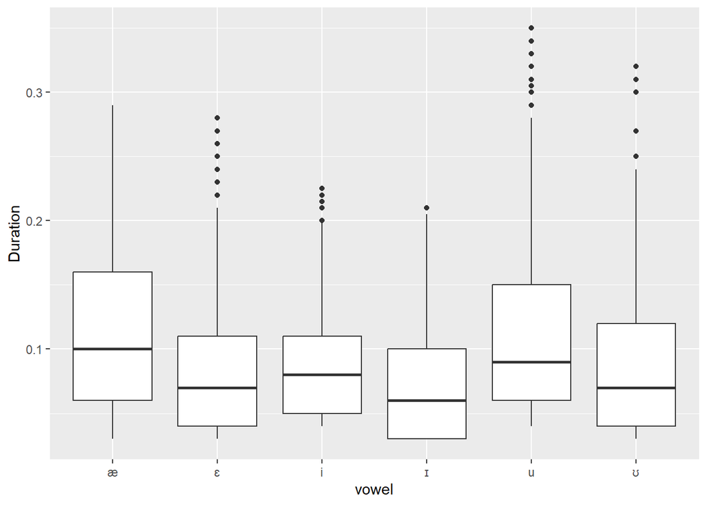

```r
bdat %>%
  ggplot(aes(x = vowel, y = Duration)) +
  geom_boxplot()
```

```r
nrow(bdat)
```

```
## [1] 7516
```

```r
bdat <- bdat  %>%
  # remove rare words
  dplyr::group_by(type, Word) %>%
  dplyr::mutate(freq = n()) %>%
  dplyr::ungroup()
# harmonize words
nnwords <- bdat %>%
  dplyr::filter(type == "CHN") %>%
  dplyr::group_by(Word) %>%
  dplyr::summarise(Freq = n()) %>%
  dplyr::pull(Word)

# remove rare vowels
bdat <- bdat %>%
  dplyr::group_by(vowel) %>%
  dplyr::mutate(fr = n()) %>%
  dplyr::filter(fr > 100) %>%
  dplyr::select(-fr) %>%
  dplyr::ungroup()
# inspect
str(bdat); nrow(bdat)
```

```
## tibble [7,516 × 29] (S3: tbl_df/tbl/data.frame)
##  $ id           : chr [1:7516] "4" "4" "8" "4" ...
##  $ Vowel        : chr [1:7516] "{" "u" "I" "u" ...
##  $ Word         : chr [1:7516] "that" "to" "with" "to" ...
##  $ F1           : num [1:7516] 714 571 439 459 479 ...
##  $ F2           : num [1:7516] 1357 1339 1234 682 996 ...
##  $ Duration     : num [1:7516] 0.21 0.08 0.11 0.09 0.06 ...
##  $ Speaker      : chr [1:7516] "CHN001" "CHN001" "CHN001" "CHN001" ...
##  $ vowel        : chr [1:7516] "æ" "u" "ɪ" "u" ...
##  $ type         : chr [1:7516] "CHN" "CHN" "CHN" "CHN" ...
##  $ Gender       : chr [1:7516] "male" "male" "male" "male" ...
##  $ Age          : int [1:7516] 20 20 20 20 20 20 20 19 19 20 ...
##  $ file         : chr [1:7516] "SM_CHN_PTJ1_001_B1_1" "SM_CHN_PTJ1_001_B1_1" "SM_CHN_PTJ1_001_B1_1" "SM_CHN_PTJ1_001_B1_1" ...
##  $ TargetVariety: chr [1:7516] "AmE" "AmE" "AmE" "AmE" ...
##  $ edist        : num [1:7516] 399 250 792 715 1033 ...
##  $ barkF1       : num [1:7516] 6.63 5.52 4.38 4.56 4.73 ...
##  $ barkF2       : num [1:7516] 10.44 10.35 9.83 6.39 8.5 ...
##  $ fspeaker     : chr [1:7516] "CHN001" "CHN001" "CHN001" "CHN001" ...
##  $ lobF1        : num [1:7516, 1] 1.22 0.0871 -0.9672 -0.8061 -0.6498 ...
##  $ lobF2        : num [1:7516, 1] -0.298 -0.345 -0.617 -2.056 -1.239 ...
##  $ normF1       : num [1:7516] 714 571 439 459 479 ...
##  $ normF2       : num [1:7516] 1357 1339 1234 682 996 ...
##  $ cF1          : num [1:7516] 5.96 4.2 5.04 4.2 5.04 ...
##  $ cF2          : num [1:7516] 10.8 10.8 11.5 10.8 11.5 ...
##  $ ED           : num [1:7516] 0.739 1.379 1.78 4.381 2.994 ...
##  $ WordType     : chr [1:7516] "grammatical" "lexical" "grammatical" "lexical" ...
##  $ Proficiency  : Factor w/ 3 levels "A2","B1","B2": 2 2 2 2 2 2 2 2 2 2 ...
##  $ WordClass    : chr [1:7516] "grammatical" "grammatical" "grammatical" "grammatical" ...
##  $ Frequency    : num [1:7516] 2.23 3.16 1.84 3.16 1.84 ...
##  $ freq         : int [1:7516] 412 919 337 919 337 170 337 919 234 292 ...
```

```
## [1] 7516
```

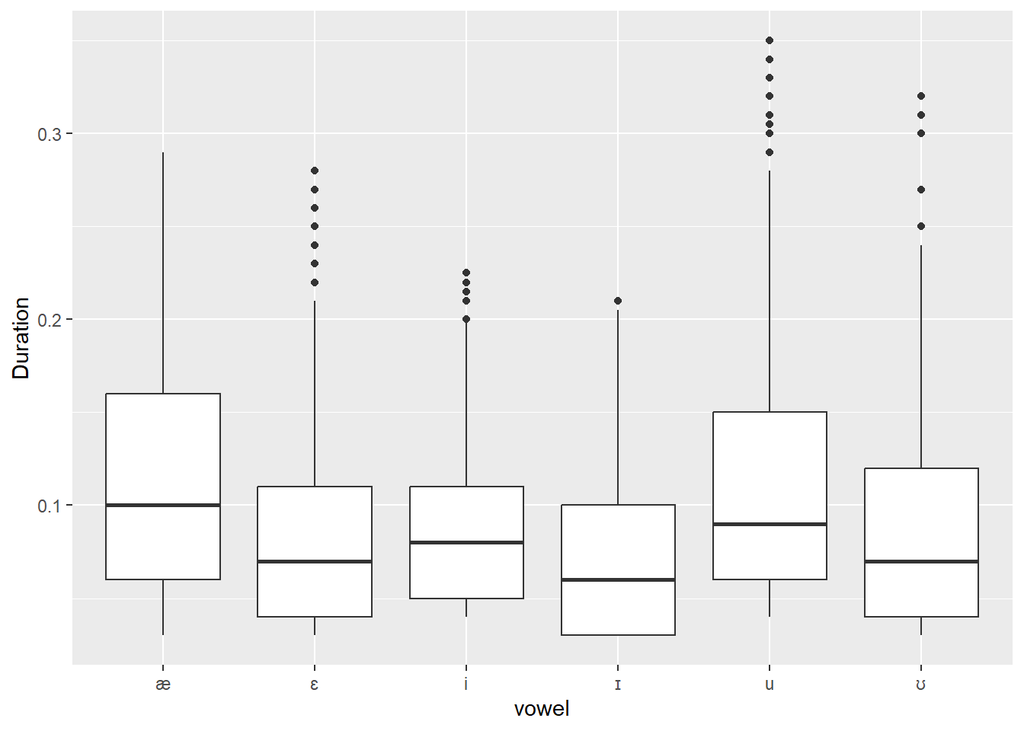

```r
bdat %>%
  ggplot(aes(x = vowel, y = Duration)) +
  geom_boxplot()
```

```r
tb2 <- bdat %>%
  dplyr::ungroup() %>%
  dplyr::mutate(Age = dplyr::case_when(Age < 30 ~ "18-29",
                                       Age < 40 ~ "30-39",
                                       Age < 50 ~ "40-49",
                                       Age > 49 ~ "50+",
                                       TRUE ~ "unknown")) %>%
  dplyr::group_by(type, Gender, Age) %>%
  dplyr::summarise(speakers = length(table(Speaker))) %>%
  tidyr::spread(Age, speakers) %>%
  dplyr::ungroup()  %>%
  adorn_totals("row")%>%
  adorn_totals("col")
# save
write.table(tb2, here::here("tables", "tb2_uhh.txt"), sep = "\t")
# inspect
tb2
```

```
##   type Gender 18-29 30-39 Total
##    CHN female    85     1    86
##    CHN   male    60     2    62
##    ENS female    25     5    30
##    ENS   male    30    27    57
##  Total      -   200    35   235
```

```r
bdat <- bdat %>%
  dplyr::mutate(F1 = as.vector(scale(F1)),
                F2 = as.vector(scale(F2)),
                Duration = as.vector(scale(Duration)),
                Age = as.vector(scale(Age)))
```

# Split data

```r
nsd <- bdat %>%
  dplyr::filter(type == "ENS") %>%
  dplyr::select(-type, -Proficiency, -Speaker, -file)  %>%
  dplyr::mutate(Word = ifelse(Word %in% nnwords, Word, "other"))%>%
  dplyr::mutate_if(is.character, factor)
# inspect
head(nsd); str(nsd)
```

```
## # A tibble: 6 × 25
##   id    Vowel Word      F1    F2 Duration vowel Gender   Age TargetVariety edist
##   <fct> <fct> <fct>  <dbl> <dbl>    <dbl> <fct> <fct>  <dbl> <fct>         <dbl>
## 1 11872 {     that   0.675 0.934  -0.134  æ     male    1.92 AmE            119.
## 2 11872 E     get   -0.203 0.159  -1.12   ɛ     male    1.92 AmE            508.
## 3 11872 {     that   0.599 0.441  -0.461  æ     male    1.92 AmE            143.
## 4 11872 u     to     0.382 0.176  -0.134  u     male    1.92 AmE            283.
## 5 11872 I     big    0.614 1.92    0.0296 ɪ     male    1.92 AmE            213.
## 6 11892 I     with   0.377 0.856  -0.297  ɪ     male    1.92 AmE            262.
## # ℹ 14 more variables: barkF1 <dbl>, barkF2 <dbl>, fspeaker <fct>,
## #   lobF1 <dbl[,1]>, lobF2 <dbl[,1]>, normF1 <dbl>, normF2 <dbl>, cF1 <dbl>,
## #   cF2 <dbl>, ED <dbl>, WordType <fct>, WordClass <fct>, Frequency <dbl>,
## #   freq <int>
```

```
## tibble [3,513 × 25] (S3: tbl_df/tbl/data.frame)
##  $ id           : Factor w/ 411 levels "11872","11892",..: 1 1 1 1 1 2 2 2 2 2 ...
##  $ Vowel        : Factor w/ 6 levels "{","E","i","I",..: 1 2 1 5 4 4 1 1 5 4 ...
##  $ Word         : Factor w/ 40 levels "bad","be","best",..: 30 11 30 32 4 40 30 30 32 40 ...
##  $ F1           : num [1:3513] 0.675 -0.203 0.599 0.382 0.614 ...
##  $ F2           : num [1:3513] 0.934 0.159 0.441 0.176 1.917 ...
##  $ Duration     : num [1:3513] -0.1339 -1.1151 -0.461 -0.1339 0.0296 ...
##  $ vowel        : Factor w/ 6 levels "æ","ɛ","i","ɪ",..: 1 2 1 5 4 4 1 1 5 4 ...
##  $ Gender       : Factor w/ 2 levels "female","male": 2 2 2 2 2 2 2 2 2 2 ...
##  $ Age          : num [1:3513] 1.92 1.92 1.92 1.92 1.92 ...
##  $ TargetVariety: Factor w/ 1 level "AmE": 1 1 1 1 1 1 1 1 1 1 ...
##  $ edist        : num [1:3513] 119 508 143 283 213 ...
##  $ barkF1       : num [1:3513] 5.62 4.46 5.53 5.25 5.55 ...
##  $ barkF2       : num [1:3513] 12.4 11.4 11.8 11.4 13.5 ...
##  $ fspeaker     : Factor w/ 87 levels "ENS002","ENS004",..: 1 1 1 1 1 2 2 2 2 2 ...
##  $ lobF1        : num [1:3513, 1] 0.264 -0.828 0.169 -0.101 0.188 ...
##  $ lobF2        : num [1:3513, 1] 0.62474 0.00106 0.22813 0.01479 1.41579 ...
##  $ normF1       : num [1:3513] 584 448 572 539 575 ...
##  $ normF2       : num [1:3513] 1825 1566 1660 1571 2155 ...
##  $ cF1          : num [1:3513] 5.96 5.05 5.96 4.2 5.04 ...
##  $ cF2          : num [1:3513] 10.8 11.1 10.8 10.8 11.5 ...
##  $ ED           : num [1:3513] 1.674 0.642 1.095 1.226 2.093 ...
##  $ WordType     : Factor w/ 2 levels "grammatical",..: 1 1 1 2 2 1 1 1 2 1 ...
##  $ WordClass    : Factor w/ 2 levels "grammatical",..: 1 1 1 1 2 1 1 1 1 1 ...
##  $ Frequency    : num [1:3513] 2.233 -0.441 2.233 3.161 -1.485 ...
##  $ freq         : int [1:3513] 873 109 873 816 12 189 873 873 816 189 ...
```

Remove impossible variables (too many levels)

```r
nrow(nsd)
```

```
## [1] 3513
```

```r
nsd <- nsd %>%
  dplyr::select(-fspeaker)
str(nsd); nrow(nsd)
```

```
## tibble [3,513 × 24] (S3: tbl_df/tbl/data.frame)
##  $ id           : Factor w/ 411 levels "11872","11892",..: 1 1 1 1 1 2 2 2 2 2 ...
##  $ Vowel        : Factor w/ 6 levels "{","E","i","I",..: 1 2 1 5 4 4 1 1 5 4 ...
##  $ Word         : Factor w/ 40 levels "bad","be","best",..: 30 11 30 32 4 40 30 30 32 40 ...
##  $ F1           : num [1:3513] 0.675 -0.203 0.599 0.382 0.614 ...
##  $ F2           : num [1:3513] 0.934 0.159 0.441 0.176 1.917 ...
##  $ Duration     : num [1:3513] -0.1339 -1.1151 -0.461 -0.1339 0.0296 ...
##  $ vowel        : Factor w/ 6 levels "æ","ɛ","i","ɪ",..: 1 2 1 5 4 4 1 1 5 4 ...
##  $ Gender       : Factor w/ 2 levels "female","male": 2 2 2 2 2 2 2 2 2 2 ...
##  $ Age          : num [1:3513] 1.92 1.92 1.92 1.92 1.92 ...
##  $ TargetVariety: Factor w/ 1 level "AmE": 1 1 1 1 1 1 1 1 1 1 ...
##  $ edist        : num [1:3513] 119 508 143 283 213 ...
##  $ barkF1       : num [1:3513] 5.62 4.46 5.53 5.25 5.55 ...
##  $ barkF2       : num [1:3513] 12.4 11.4 11.8 11.4 13.5 ...
##  $ lobF1        : num [1:3513, 1] 0.264 -0.828 0.169 -0.101 0.188 ...
##  $ lobF2        : num [1:3513, 1] 0.62474 0.00106 0.22813 0.01479 1.41579 ...
##  $ normF1       : num [1:3513] 584 448 572 539 575 ...
##  $ normF2       : num [1:3513] 1825 1566 1660 1571 2155 ...
##  $ cF1          : num [1:3513] 5.96 5.05 5.96 4.2 5.04 ...
##  $ cF2          : num [1:3513] 10.8 11.1 10.8 10.8 11.5 ...
##  $ ED           : num [1:3513] 1.674 0.642 1.095 1.226 2.093 ...
##  $ WordType     : Factor w/ 2 levels "grammatical",..: 1 1 1 2 2 1 1 1 2 1 ...
##  $ WordClass    : Factor w/ 2 levels "grammatical",..: 1 1 1 1 2 1 1 1 1 1 ...
##  $ Frequency    : num [1:3513] 2.233 -0.441 2.233 3.161 -1.485 ...
##  $ freq         : int [1:3513] 873 109 873 816 12 189 873 873 816 189 ...
```

```
## [1] 3513
```

## Split native speaker data into test and training set

```r
# add id to data
nsd <- nsd %>% dplyr::mutate(id = 1:nrow(.))
# create training set (70%)
nsdtrain <- nsd %>% dplyr::sample_frac(0.70)
# create test set (30%)
nsdtest  <- dplyr::anti_join(nsd, nsdtrain, by = 'id') %>%
  dplyr::select(-id)
# remove id column
nsdtrain <- nsdtrain %>% dplyr::select(-id)
# inspect
head(nsdtrain); head(nsdtest)
```

```
## # A tibble: 6 × 23
##   Vowel Word       F1     F2 Duration vowel Gender    Age TargetVariety edist
##   <fct> <fct>   <dbl>  <dbl>    <dbl> <fct> <fct>   <dbl> <fct>         <dbl>
## 1 {     that   1.20   -0.881   1.01   æ     male   -0.144 AmE            537.
## 2 i     be    -0.0696  2.53   -0.952  i     male    2.30  AmE            185.
## 3 I     his   -0.641   1.10    0.0296 ɪ     male    0.982 AmE            148.
## 4 i     be    -1.23    1.18   -0.461  i     female  2.11  AmE            939.
## 5 {     that   1.04    1.05   -0.625  æ     male    0.232 AmE            116.
## 6 I     with  -0.282   0.273  -0.952  ɪ     female -0.707 AmE            739.
## # ℹ 13 more variables: barkF1 <dbl>, barkF2 <dbl>, lobF1 <dbl[,1]>,
## #   lobF2 <dbl[,1]>, normF1 <dbl>, normF2 <dbl>, cF1 <dbl>, cF2 <dbl>,
## #   ED <dbl>, WordType <fct>, WordClass <fct>, Frequency <dbl>, freq <int>
```

```
## # A tibble: 6 × 23
##   Vowel Word      F1     F2 Duration vowel Gender   Age TargetVariety edist
##   <fct> <fct>  <dbl>  <dbl>    <dbl> <fct> <fct>  <dbl> <fct>         <dbl>
## 1 E     get   -0.203  0.159   -1.12  ɛ     male    1.92 AmE            508.
## 2 {     that   0.599  0.441   -0.461 æ     male    1.92 AmE            143.
## 3 I     with   0.377  0.856   -0.297 ɪ     male    1.92 AmE            262.
## 4 {     that   0.899 -0.668   -0.624 æ     male    1.92 AmE            470.
## 5 {     that   1.25  -0.345    1.50  æ     male    1.92 AmE            358.
## 6 I     with   0.444 -0.113    0.193 ɪ     male    1.92 AmE            570.
## # ℹ 13 more variables: barkF1 <dbl>, barkF2 <dbl>, lobF1 <dbl[,1]>,
## #   lobF2 <dbl[,1]>, normF1 <dbl>, normF2 <dbl>, cF1 <dbl>, cF2 <dbl>,
## #   ED <dbl>, WordType <fct>, WordClass <fct>, Frequency <dbl>, freq <int>
```

```r
nnsd <- bdat %>%
  dplyr::filter(type != "ENS") %>%
  droplevels() %>%
  dplyr::select(-file, -type, -fspeaker)
# save predictors associated with proficiency for later
pred_nns <- nnsd %>% dplyr::select(Speaker, Proficiency)
# remove proficiency variables (for now)
nnsd <- nnsd %>%
  dplyr::select(-Proficiency, -Speaker)
# inspect data
head(nnsd); str(nnsd)
```

```
## # A tibble: 6 × 24
##   id    Vowel Word        F1     F2 Duration vowel Gender    Age TargetVariety
##   <chr> <chr> <chr>    <dbl>  <dbl>    <dbl> <chr> <chr>   <dbl> <chr>
## 1 4     {     that   1.51    -0.464    1.83  æ     male   -0.707 AmE
## 2 4     u     to     0.593   -0.518   -0.297 u     male   -0.707 AmE
## 3 8     I     with  -0.261   -0.830    0.193 ɪ     male   -0.707 AmE
## 4 4     u     to    -0.130   -2.48    -0.134 u     male   -0.707 AmE
## 5 4     I     with  -0.00373 -1.54    -0.625 ɪ     male   -0.707 AmE
## 6 8     u     do     0.188   -0.817   -0.625 u     male   -0.707 AmE
## # ℹ 14 more variables: edist <dbl>, barkF1 <dbl>, barkF2 <dbl>,
## #   lobF1 <dbl[,1]>, lobF2 <dbl[,1]>, normF1 <dbl>, normF2 <dbl>, cF1 <dbl>,
## #   cF2 <dbl>, ED <dbl>, WordType <chr>, WordClass <chr>, Frequency <dbl>,
## #   freq <int>
```

```
## tibble [4,003 × 24] (S3: tbl_df/tbl/data.frame)
##  $ id           : chr [1:4003] "4" "4" "8" "4" ...
##  $ Vowel        : chr [1:4003] "{" "u" "I" "u" ...
##  $ Word         : chr [1:4003] "that" "to" "with" "to" ...
##  $ F1           : num [1:4003] 1.511 0.59321 -0.26085 -0.13032 -0.00373 ...
##  $ F2           : num [1:4003] -0.464 -0.518 -0.83 -2.476 -1.541 ...
##  $ Duration     : num [1:4003] 1.829 -0.297 0.193 -0.134 -0.625 ...
##  $ vowel        : chr [1:4003] "æ" "u" "ɪ" "u" ...
##  $ Gender       : chr [1:4003] "male" "male" "male" "male" ...
##  $ Age          : num [1:4003] -0.707 -0.707 -0.707 -0.707 -0.707 ...
##  $ TargetVariety: chr [1:4003] "AmE" "AmE" "AmE" "AmE" ...
##  $ edist        : num [1:4003] 399 250 792 715 1033 ...
##  $ barkF1       : num [1:4003] 6.63 5.52 4.38 4.56 4.73 ...
##  $ barkF2       : num [1:4003] 10.44 10.35 9.83 6.39 8.5 ...
##  $ lobF1        : num [1:4003, 1] 1.22 0.0871 -0.9672 -0.8061 -0.6498 ...
##  $ lobF2        : num [1:4003, 1] -0.298 -0.345 -0.617 -2.056 -1.239 ...
##  $ normF1       : num [1:4003] 714 571 439 459 479 ...
##  $ normF2       : num [1:4003] 1357 1339 1234 682 996 ...
##  $ cF1          : num [1:4003] 5.96 4.2 5.04 4.2 5.04 ...
##  $ cF2          : num [1:4003] 10.8 10.8 11.5 10.8 11.5 ...
##  $ ED           : num [1:4003] 0.739 1.379 1.78 4.381 2.994 ...
##  $ WordType     : chr [1:4003] "grammatical" "lexical" "grammatical" "lexical" ...
##  $ WordClass    : chr [1:4003] "grammatical" "grammatical" "grammatical" "grammatical" ...
##  $ Frequency    : num [1:4003] 2.23 3.16 1.84 3.16 1.84 ...
##  $ freq         : int [1:4003] 412 919 337 919 337 170 337 919 234 292 ...
```

# Harmonize words

```r
nswords <- nsdtrain %>%
  dplyr::group_by(Word) %>%
  dplyr::summarise(Freq = n()) %>%
  dplyr::pull(Word)
nnsd <- nnsd %>%
  dplyr::mutate(Word = ifelse(Word %in% nswords, Word, "other")) %>%
  dplyr::mutate_if(is.character, factor)
# inspect
str(nnsd); str(nsdtrain); nswords
```

```
## tibble [4,003 × 24] (S3: tbl_df/tbl/data.frame)
##  $ id           : Factor w/ 639 levels "10004","1002",..: 276 276 516 276 276 516 178 300 300 407 ...
##  $ Vowel        : Factor w/ 6 levels "{","E","i","I",..: 1 5 4 5 4 5 4 5 4 3 ...
##  $ Word         : Factor w/ 39 levels "bad","be","best",..: 29 31 39 31 39 9 39 31 30 2 ...
##  $ F1           : num [1:4003] 1.511 0.59321 -0.26085 -0.13032 -0.00373 ...
##  $ F2           : num [1:4003] -0.464 -0.518 -0.83 -2.476 -1.541 ...
##  $ Duration     : num [1:4003] 1.829 -0.297 0.193 -0.134 -0.625 ...
##  $ vowel        : Factor w/ 6 levels "æ","ɛ","i","ɪ",..: 1 5 4 5 4 5 4 5 4 3 ...
##  $ Gender       : Factor w/ 2 levels "female","male": 2 2 2 2 2 2 2 2 2 1 ...
##  $ Age          : num [1:4003] -0.707 -0.707 -0.707 -0.707 -0.707 ...
##  $ TargetVariety: Factor w/ 1 level "AmE": 1 1 1 1 1 1 1 1 1 1 ...
##  $ edist        : num [1:4003] 399 250 792 715 1033 ...
##  $ barkF1       : num [1:4003] 6.63 5.52 4.38 4.56 4.73 ...
##  $ barkF2       : num [1:4003] 10.44 10.35 9.83 6.39 8.5 ...
##  $ lobF1        : num [1:4003, 1] 1.22 0.0871 -0.9672 -0.8061 -0.6498 ...
##  $ lobF2        : num [1:4003, 1] -0.298 -0.345 -0.617 -2.056 -1.239 ...
##  $ normF1       : num [1:4003] 714 571 439 459 479 ...
##  $ normF2       : num [1:4003] 1357 1339 1234 682 996 ...
##  $ cF1          : num [1:4003] 5.96 4.2 5.04 4.2 5.04 ...
##  $ cF2          : num [1:4003] 10.8 10.8 11.5 10.8 11.5 ...
##  $ ED           : num [1:4003] 0.739 1.379 1.78 4.381 2.994 ...
##  $ WordType     : Factor w/ 2 levels "grammatical",..: 1 2 1 2 1 1 1 2 1 1 ...
##  $ WordClass    : Factor w/ 2 levels "grammatical",..: 1 1 1 1 1 1 1 1 1 1 ...
##  $ Frequency    : num [1:4003] 2.23 3.16 1.84 3.16 1.84 ...
##  $ freq         : int [1:4003] 412 919 337 919 337 170 337 919 234 292 ...
```

```
## tibble [2,459 × 23] (S3: tbl_df/tbl/data.frame)
##  $ Vowel        : Factor w/ 6 levels "{","E","i","I",..: 1 3 4 3 1 4 5 5 3 1 ...
##  $ Word         : Factor w/ 40 levels "bad","be","best",..: 30 2 18 2 30 40 9 9 2 30 ...
##  $ F1           : num [1:2459] 1.2026 -0.0696 -0.6407 -1.2286 1.0425 ...
##  $ F2           : num [1:2459] -0.881 2.533 1.098 1.179 1.048 ...
##  $ Duration     : num [1:2459] 1.0107 -0.9516 0.0296 -0.461 -0.6245 ...
##  $ vowel        : Factor w/ 6 levels "æ","ɛ","i","ɪ",..: 1 3 4 3 1 4 5 5 3 1 ...
##  $ Gender       : Factor w/ 2 levels "female","male": 2 2 2 1 2 1 2 2 2 1 ...
##  $ Age          : num [1:2459] -0.144 2.296 0.982 2.108 0.232 ...
##  $ TargetVariety: Factor w/ 1 level "AmE": 1 1 1 1 1 1 1 1 1 1 ...
##  $ edist        : num [1:2459] 537 185 148 939 116 ...
##  $ barkF1       : num [1:2459] 6.27 4.64 3.83 2.92 6.08 ...
##  $ barkF2       : num [1:2459] 9.74 14.12 12.6 12.69 12.54 ...
##  $ lobF1        : num [1:2459, 1] 0.919 -0.662 -1.372 -0.722 0.72 ...
##  $ lobF2        : num [1:2459, 1] -0.835 1.911 0.757 1.252 0.717 ...
##  $ normF1       : num [1:2459] 666 469 380 289 641 ...
##  $ normF2       : num [1:2459] 1217 2362 1880 1908 1864 ...
##  $ cF1          : num [1:2459] 5.96 4.09 5.04 4.09 5.96 ...
##  $ cF2          : num [1:2459] 10.8 12.8 11.5 12.8 10.8 ...
##  $ ED           : num [1:2459] 1.06 1.39 1.65 1.18 1.78 ...
##  $ WordType     : Factor w/ 2 levels "grammatical",..: 1 1 1 1 1 1 1 1 1 1 ...
##  $ WordClass    : Factor w/ 2 levels "grammatical",..: 1 1 1 1 1 1 1 1 1 1 ...
##  $ Frequency    : num [1:2459] 2.23 1.79 1.62 1.79 2.23 ...
##  $ freq         : int [1:2459] 873 586 8 586 873 189 104 104 586 873 ...
```

```
##  [1] bad   be    best  big   book  books death did   do    gas   get   gets
## [13] good  guess had   has   he    his   keep  kids  other past  put   said
## [25] see   she   sit   step  that  this  to    too   took  two   we    week
## [37] who   wish  with
## 40 Levels: bad be best big book books death did do gas get gets good ... with
```

Remove superfluous predictors

```r
# nnsd
nnsd <- nnsd %>%
  dplyr::select(-id, -Vowel, -TargetVariety, -edist, -barkF1, -barkF2, -lobF1,
                -lobF2, -normF1, -normF2, -cF1, -cF2, -ED, -WordType, -freq) %>%
  dplyr::rename(Vowel = vowel)
# nsdtrain
nsdtrain <- nsdtrain %>%
  dplyr::select(-Vowel, -TargetVariety, -edist, -barkF1, -barkF2, -lobF1,
                -lobF2, -normF1, -normF2, -cF1, -cF2, -ED, -WordType, -freq) %>%
  dplyr::rename(Vowel = vowel)
# nsdtest
nsdtest <- nsdtest %>%
  dplyr::select(-Vowel, -TargetVariety, -edist, -barkF1, -barkF2, -lobF1,
                -lobF2, -normF1, -normF2, -cF1, -cF2, -ED, -WordType, -freq) %>%
  dplyr::rename(Vowel = vowel)
# inspect
colnames(nnsd); colnames(nsdtrain); colnames(nsdtest)
```

```
## [1] "Word"      "F1"        "F2"        "Duration"  "Vowel"     "Gender"
## [7] "Age"       "WordClass" "Frequency"
```

```
## [1] "Word"      "F1"        "F2"        "Duration"  "Vowel"     "Gender"
## [7] "Age"       "WordClass" "Frequency"
```

```
## [1] "Word"      "F1"        "F2"        "Duration"  "Vowel"     "Gender"
## [7] "Age"       "WordClass" "Frequency"
```

# MuPDARF

Prepare data

```r
wrds1 <- names(table(nsdtest$Word))[table(nsdtest$Word) > 0]
wrds2 <- names(table(nsdtrain$Word))[table(nsdtrain$Word) > 0]
wrds3 <- names(table(nnsd$Word))[table(nnsd$Word) > 0]
wrds <- Reduce(intersect, list(wrds1, wrds2, wrds3))
# apply to data sets
nsdtest <- nsdtest %>%
  dplyr::mutate(Word = ifelse(Word %in% wrds, as.character(Word), "other"))
nsdtrain <- nsdtrain %>%
  dplyr::mutate(Word = ifelse(Word %in% wrds, as.character(Word), "other"))
nnsd <- nnsd %>%
  dplyr::mutate(Word = ifelse(Word %in% wrds, as.character(Word), "other"))
# inspect
wrds
```

```
##  [1] "bad"   "be"    "best"  "big"   "books" "did"   "do"    "gas"   "get"
## [10] "gets"  "good"  "guess" "had"   "has"   "he"    "his"   "keep"  "other"
## [19] "put"   "said"  "see"   "she"   "sit"   "that"  "this"  "to"    "too"
## [28] "two"   "we"    "who"   "wish"  "with"
```

## RF NS

Now, we perform a random forest analysis of the native speaker data.

Now, we perform a random forest analysis of the native speaker data.

```r
# set seed
set.seed(sum(utf8ToInt("RFNS")))
nsrf <- randomForest::randomForest(Vowel ~ ., data=nsdtrain, ntree=1000, proximity=TRUE, importance=TRUE)
# inspect rf results
nsrf
```

```
##
## Call:
##  randomForest(formula = Vowel ~ ., data = nsdtrain, ntree = 1000,      proximity = TRUE, importance = TRUE)
##                Type of random forest: classification
##                      Number of trees: 1000
## No. of variables tried at each split: 2
##
##         OOB estimate of  error rate: 6.51%
## Confusion matrix:
##     æ   ɛ   i   ɪ   u  ʊ class.error
## æ 585  15   0   3   0  0 0.029850746
## ɛ  83 162   0   2   0  0 0.344129555
## i   0   1 472   6   2  0 0.018711019
## ɪ   2   6  20 269   5  0 0.109271523
## u   0   2   0   0 746  0 0.002673797
## ʊ   2  10   1   0   0 65 0.166666667
```

visualise misclassification

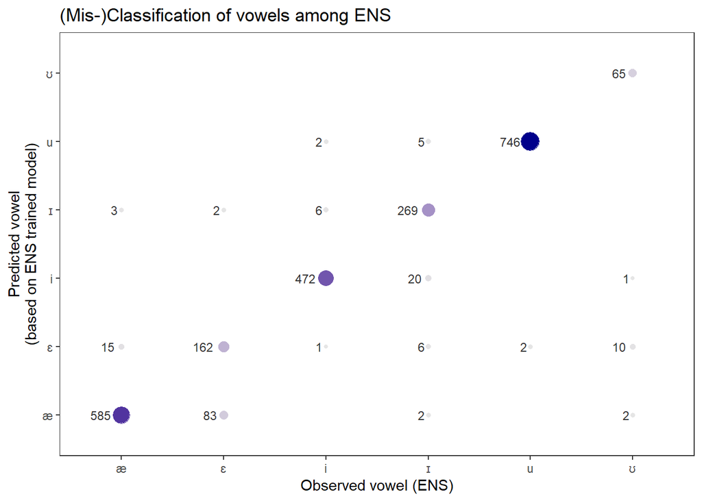

```r
nmc <- nsrf$confusion[, -7] %>%
  as.data.frame() %>%
  dplyr::mutate(Vowel = rownames(.)) %>%
  tidyr::gather(NativeChoice, freq, æ:ʊ) %>%
  dplyr::mutate_if(is.character, factor) %>%
  dplyr::mutate(freq = ifelse(freq == 0, NA, freq))

ggplot(nmc, aes(x=Vowel, y=NativeChoice, color=freq, size=freq, label=freq)) +
  #geom_tile()+
  geom_point() +
  geom_text(size = 3, hjust=1.5, color = "gray20")+
  scale_color_gradient(high="darkblue", low="gray90") +
  labs(x = "Observed vowel (ENS)", y = "Predicted vowel\n(based on ENS trained model)", title = "(Mis-)Classification of vowels among ENS") +
  theme_bw()+
  theme(legend.position = "none",
        panel.grid.major = element_blank(),
        panel.grid.minor = element_blank())
```

```r
# save
ggsave(here::here("images", "misclass_ns.png"), width = 5, height = 4)
```

Next, we plot the results.

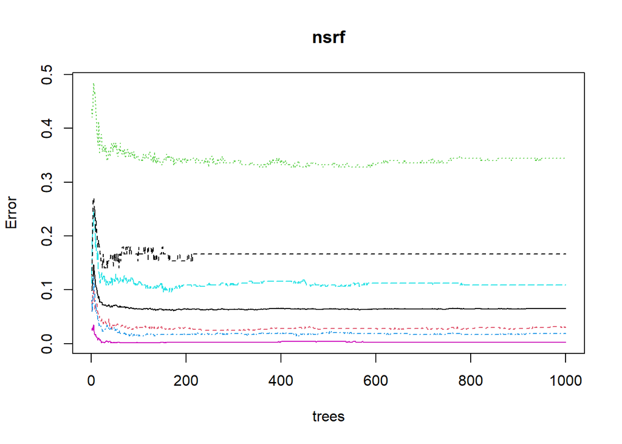

```r
plot(nsrf)
```

Now, we plot the out-of-bag error frequencies.

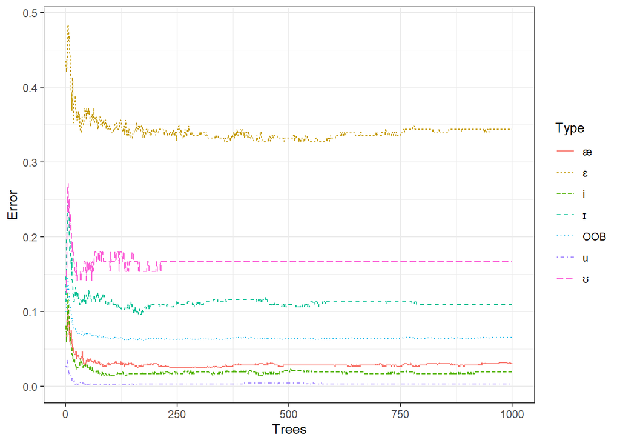

```r
# plot new precision/error rate
oob.error.data <- data.frame(
  Trees = rep(1:nrow(nsrf$err.rate), times=ncol(nsrf$err.rate)),
  Type = rep(dimnames(nsrf$err.rate)[[2]], each=nrow(nsrf$err.rate)),
  Error = as.vector(unlist(nsrf$err.rate)))
# visualise
ggplot(data=oob.error.data, aes(x=Trees, y=Error)) +
  geom_line(aes(color=Type, linetype = Type)) +
  theme_bw()
```

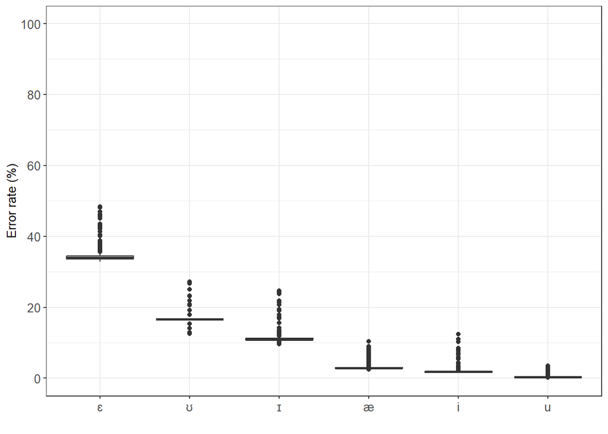

```r
oob.error.data %>%
  dplyr::filter(Type != "OOB") %>%
  ggplot(aes(x=reorder(Type, -Error, mean), y= Error,  group = Type)) +
  geom_boxplot(fill = "lightgray") +
  coord_cartesian(ylim = c(0, 1)) +
  theme_bw(base_size = 10) +
  theme(axis.text.x = element_text(size=10),
        axis.text.y = element_text(size=10, face="plain")) +
  labs(x = "", y = "Error rate (%)") +
  scale_y_continuous(limits = c(0, 1),
                     labels = seq(0, 100, 20),
                     breaks = seq(0, 1, .2)) +
  scale_color_manual(guide = FALSE)
```

```r
# save
ggsave(here::here("images", "rf_ns.png"))
```

Now, we check the error rates and accuracy and also check how much the model performs better than a base-line model.

```r
# determine accuracy by prediction
# prediction
pnsrf <- predict(nsrf, nsdtest)
# create confusion matrix
confusionMatrix(pnsrf, nsdtest$Vowel)
```

```
## Confusion Matrix and Statistics
##
##           Reference
## Prediction   æ   ɛ   i   ɪ   u   ʊ
##          æ 260  33   0   0   0   0
##          ɛ   8  55   1   6   0   1
##          i   1   2 178  13   1   1
##          ɪ   0   3   2 123   0   0
##          u   0   0   0   2 329   0
##          ʊ   0   0   0   0   0  35
##
## Overall Statistics
##
##                Accuracy : 0.9298
##                  95% CI : (0.9127, 0.9445)
##     No Information Rate : 0.3131
##     P-Value [Acc > NIR] : < 0.00000000000000022
##
##                   Kappa : 0.9094
##
##  Mcnemar's Test P-Value : NA
##
## Statistics by Class:
##
##                      Class: æ Class: ɛ Class: i Class: ɪ Class: u Class: ʊ
## Sensitivity            0.9665  0.59140   0.9834   0.8542   0.9970  0.94595
## Specificity            0.9580  0.98335   0.9794   0.9945   0.9972  1.00000
## Pos Pred Value         0.8874  0.77465   0.9082   0.9609   0.9940  1.00000
## Neg Pred Value         0.9882  0.96134   0.9965   0.9773   0.9986  0.99804
## Prevalence             0.2552  0.08824   0.1717   0.1366   0.3131  0.03510
## Detection Rate         0.2467  0.05218   0.1689   0.1167   0.3121  0.03321
## Detection Prevalence   0.2780  0.06736   0.1860   0.1214   0.3140  0.03321
## Balanced Accuracy      0.9623  0.78737   0.9814   0.9243   0.9971  0.97297
```

```r
cmnsd <- confusionMatrix(pnsrf, nsdtest$Vowel)
# calculate increase in prediction accuracy compared to base-line model
cmnsd$overall[1]
```

```
##  Accuracy
## 0.9297913
```

```r
cmnsd$overall[5]
```

```
## AccuracyNull
##     0.313093
```

```r
cmnsd$overall[1]/cmnsd$overall[5]
```

```
## Accuracy
## 2.969697
```

Now, we inspect which variables are important for the predictions.

```r
impdat <- data.frame(
  Measure = c(rep("Accuracy", length(nsrf$importance[,"MeanDecreaseAccuracy"])),
              rep("Gini", length(nsrf$importance[,"MeanDecreaseGini"]))),
  Label = rep(dimnames(nsrf$importance)[[1]], 2),
  Value = c(nsrf$importance[,"MeanDecreaseAccuracy"], nsrf$importance[,"MeanDecreaseGini"]))
# ordering
impdat <- impdat %>%
  dplyr::group_by(Measure) %>%
  dplyr::mutate(NormMeasure = scale(Value))
# inspect
impdat
```

```
## # A tibble: 16 × 4
## # Groups:   Measure [2]
##    Measure  Label         Value NormMeasure[,1]
##    <chr>    <chr>         <dbl>           <dbl>
##  1 Accuracy Word        0.319            1.43
##  2 Accuracy F1          0.0996          -0.120
##  3 Accuracy F2          0.0496          -0.472
##  4 Accuracy Duration    0.0320          -0.597
##  5 Accuracy Gender      0.0129          -0.731
##  6 Accuracy Age         0.00440         -0.791
##  7 Accuracy WordClass   0.0529          -0.450
##  8 Accuracy Frequency   0.363            1.74
##  9 Gini     Word      570.               1.42
## 10 Gini     F1        241.               0.0543
## 11 Gini     F2        179.              -0.204
## 12 Gini     Duration   99.2             -0.535
## 13 Gini     Gender     17.7             -0.873
## 14 Gini     Age        46.8             -0.753
## 15 Gini     WordClass  44.1             -0.764
## 16 Gini     Frequency 627.               1.66
```

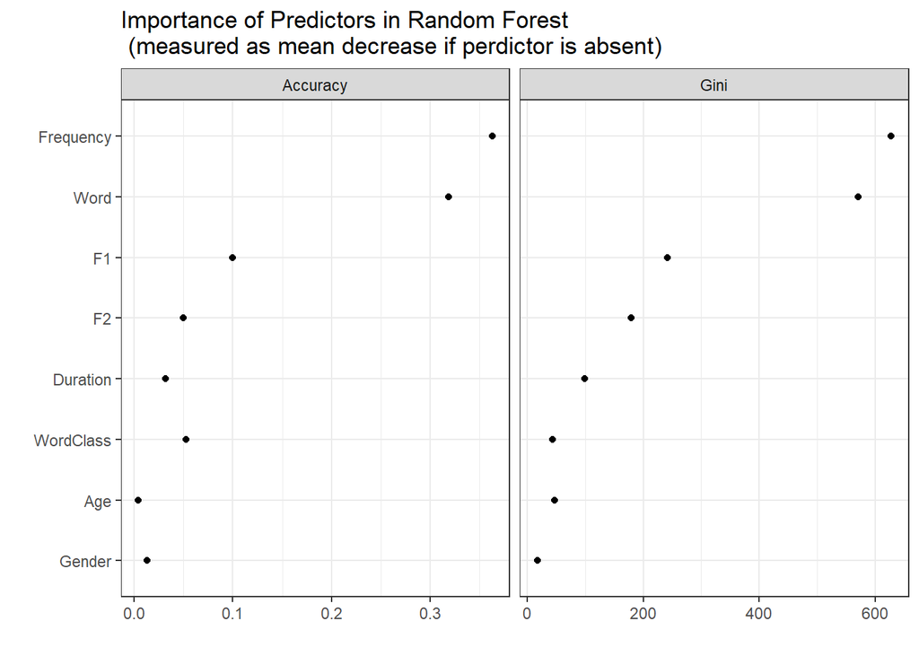

```r
impdat %>%
  ggplot(aes(x = reorder(Label, NormMeasure), y = Value)) +
  geom_point() +
  facet_grid(~Measure, scales="free") +
  coord_flip() +
  theme_bw() +
  labs(x = "", y = "", title = "Importance of Predictors in Random Forest\n (measured as mean decrease if perdictor is absent)")
```

```r
ggsave(here::here("images", "VarImpRFnsd.png"), width = 6, height = 4)
```

```r
errors_nsd <- nsdtest %>%
  dplyr::mutate(Prediction = predict(nsrf, nsdtest),
                Error = ifelse(Vowel == Prediction, 0, 1)) %>%
  dplyr::group_by(Vowel) %>%
  dplyr::summarise(all = n(),
                   errors = sum(Error),
                   Percent = round(errors/all*100, 1)) %>%
  dplyr::ungroup() %>%
    dplyr::mutate(Vowel = as.character(Vowel),
                  Type = "ENS") %>%
  dplyr::select(-all, -errors)
# inspect
head(errors_nsd)
```

```
## # A tibble: 6 × 3
##   Vowel Percent Type
##   <chr>   <dbl> <chr>
## 1 æ         3.3 ENS
## 2 ɛ        40.9 ENS
## 3 i         1.7 ENS
## 4 ɪ        14.6 ENS
## 5 u         0.3 ENS
## 6 ʊ         5.4 ENS
```

## RF NNS

Now, we use the random forest analysis of the native speakers to predict what vowel a native speaker would have produced in the non-native speaker contexts In a first step, we extract only non-native speaker data.

Next, we use the random forest analysis of the native speakers to predict what vowel a native speaker would have used.

```r
# extract prediction for training data
pnns <- predict(nsrf, nnsd)
# inspect predictions
head(pnns); head(nnsd$Vowel)
```

```
## 1 2 3 4 5 6
## æ u ɪ u ɪ u
## Levels: æ ɛ i ɪ u ʊ
```

```
## [1] æ u ɪ u ɪ u
## Levels: æ ɛ i ɪ u ʊ
```

Now, we create a confusion matrix to check the accuracy of the prediction

```r
confusionMatrix(pnns, nnsd$Vowel)
```

```
## Confusion Matrix and Statistics
##
##           Reference
## Prediction    æ    ɛ    i    ɪ    u    ʊ
##          æ  548   71    0    3    0    4
##          ɛ   25  186    4   12    1   25
##          i    1    1  827   99    0    0
##          ɪ    2    4    8  735    0    2
##          u    0    0    8    9 1214    3
##          ʊ    0    1    0    0    0  210
##
## Overall Statistics
##
##                Accuracy : 0.9293
##                  95% CI : (0.9209, 0.9371)
##     No Information Rate : 0.3035
##     P-Value [Acc > NIR] : < 0.00000000000000022
##
##                   Kappa : 0.9102
##
##  Mcnemar's Test P-Value : NA
##
## Statistics by Class:
##
##                      Class: æ Class: ɛ Class: i Class: ɪ Class: u Class: ʊ
## Sensitivity            0.9514  0.70722   0.9764   0.8566   0.9992  0.86066
## Specificity            0.9772  0.98209   0.9680   0.9949   0.9928  0.99973
## Pos Pred Value         0.8754  0.73518   0.8912   0.9787   0.9838  0.99526
## Neg Pred Value         0.9917  0.97947   0.9935   0.9622   0.9996  0.99103
## Prevalence             0.1439  0.06570   0.2116   0.2143   0.3035  0.06095
## Detection Rate         0.1369  0.04647   0.2066   0.1836   0.3033  0.05246
## Detection Prevalence   0.1564  0.06320   0.2318   0.1876   0.3083  0.05271
## Balanced Accuracy      0.9643  0.84465   0.9722   0.9258   0.9960  0.93019
```

```r
cmnsd <- confusionMatrix(pnns, nnsd$Vowel)
# calculate increase in prediction accuracy compared to base-line model
cmnsd$overall[1]
```

```
## Accuracy
## 0.929303
```

```r
cmnsd$overall[5]
```

```
## AccuracyNull
##    0.3035224
```

```r
cmnsd$overall[1]/cmnsd$overall[5]
```

```
## Accuracy
## 3.061728
```

Next, we add the difference between predictions and observed amplification to the data.

```r
# add native choice prediction to data
nnsd <- nnsd %>%
  dplyr::mutate(NativeChoice = as.vector(pnns),
                NativeChoice = as.factor(NativeChoice)) %>%
  # code if choice of nns is nativelike or not
  dplyr::mutate(Vowel = as.character(Vowel),
                NativeChoice = as.character(NativeChoice),
                NonNativeLike = ifelse(Vowel == NativeChoice, 0, 1))

# inspect new data
head(nnsd)
```

```
## # A tibble: 6 × 11
##   Word        F1     F2 Duration Vowel Gender    Age WordClass   Frequency
##   <chr>    <dbl>  <dbl>    <dbl> <chr> <fct>   <dbl> <fct>           <dbl>
## 1 that   1.51    -0.464    1.83  æ     male   -0.707 grammatical     2.23
## 2 to     0.593   -0.518   -0.297 u     male   -0.707 grammatical     3.16
## 3 with  -0.261   -0.830    0.193 ɪ     male   -0.707 grammatical     1.84
## 4 to    -0.130   -2.48    -0.134 u     male   -0.707 grammatical     3.16
## 5 with  -0.00373 -1.54    -0.625 ɪ     male   -0.707 grammatical     1.84
## 6 do     0.188   -0.817   -0.625 u     male   -0.707 grammatical     0.130
## # ℹ 2 more variables: NativeChoice <chr>, NonNativeLike <dbl>
```

## Inspect words where the vowels are wrong

```r
errors_words <- nnsd %>%
  dplyr::filter(NonNativeLike == 1) %>%
  dplyr::select(Word, Vowel, NativeChoice) %>%
  dplyr::group_by(Word, Vowel, NativeChoice) %>%
  dplyr::summarise(freq = n()) %>%
  dplyr::ungroup() %>%
  dplyr::arrange(-freq)
# inspect
errors_words
```

```
## # A tibble: 50 × 4
##    Word  Vowel NativeChoice  freq
##    <chr> <chr> <chr>        <int>
##  1 we    ɪ     i               75
##  2 that  ɛ     æ               61
##  3 has   æ     ɛ               18
##  4 his   ɪ     i               12
##  5 put   ʊ     ɛ               11
##  6 we    ɪ     u                9
##  7 books ʊ     ɛ                7
##  8 other ʊ     ɛ                7
##  9 to    i     u                7
## 10 be    ɪ     i                5
## # ℹ 40 more rows
```

```r
table(errors_words$Word, errors_words$NativeChoice)
```

```
##
##         æ ɛ i ɪ u ʊ
##   be    0 0 1 1 0 0
##   best  1 0 0 1 0 0
##   big   0 1 0 1 0 0
##   books 1 1 0 1 0 0
##   did   0 1 0 0 0 0
##   gas   0 0 0 1 0 0
##   guess 1 0 0 0 0 0
##   had   1 1 1 1 0 0
##   has   1 1 1 0 0 0
##   he    0 0 1 0 0 0
##   his   1 0 1 0 0 0
##   other 2 5 1 2 0 1
##   put   0 1 0 0 0 0
##   see   0 1 0 0 0 0
##   she   1 2 1 1 0 0
##   sit   0 1 0 0 0 0
##   that  1 1 0 0 0 0
##   this  0 0 1 0 0 0
##   to    0 0 0 0 2 0
##   too   0 0 0 0 1 0
##   we    0 0 1 1 1 0
```

visualise misclassification

```r
pmc <- nnsd %>%
  dplyr::select(Vowel, NativeChoice) %>%
  dplyr::mutate_if(is.character, factor) %>%
  dplyr::group_by(Vowel, NativeChoice) %>%
  dplyr::summarise(freq = n())
```

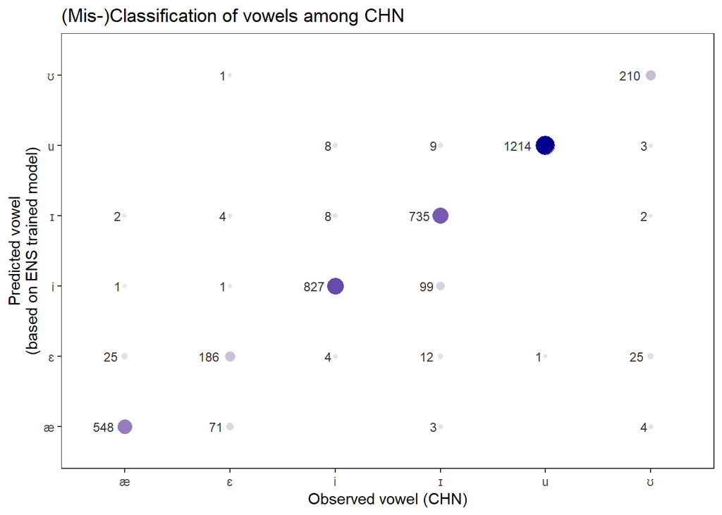

```r
ggplot(pmc, aes(x=Vowel, y=NativeChoice, color=freq, size=freq, label=freq)) +
  #geom_tile()+
  geom_point() +
  geom_text(size = 3, hjust=1.5, color = "gray20")+
  scale_color_gradient(high="darkblue", low="gray90") +
  labs(x = "Observed vowel (CHN)", y = "Predicted vowel\n(based on ENS trained model)", title = "(Mis-)Classification of vowels among CHN") +
  theme_bw()+
  theme(legend.position = "none",
        panel.grid.major = element_blank(),
        panel.grid.minor = element_blank())
```

```r
# save
ggsave(here::here("images", "misclass_nns.png"), width = 5, height = 4)
```

```r
errors_nnsd <- nnsd %>%
  dplyr::group_by(Vowel, NonNativeLike) %>%
  dplyr::summarise(freq = n()) %>%
  dplyr::ungroup() %>%
  dplyr::group_by(Vowel) %>%
  dplyr::summarise(all = sum(freq),
                   Percent = round(freq/all*100, 1),
                   NonNativeLike = NonNativeLike) %>%
  dplyr::ungroup() %>%
  dplyr::filter(NonNativeLike == 1) %>%
  dplyr::select(-all, -NonNativeLike) %>%
  dplyr::mutate(Type = "CHN")
# inspect
head(errors_nnsd); errors_nsd
```

```
## # A tibble: 6 × 3
##   Vowel Percent Type
##   <chr>   <dbl> <chr>
## 1 i         2.4 CHN
## 2 u         0.1 CHN
## 3 æ         4.9 CHN
## 4 ɛ        29.3 CHN
## 5 ɪ        14.3 CHN
## 6 ʊ        13.9 CHN
```

```
## # A tibble: 6 × 3
##   Vowel Percent Type
##   <chr>   <dbl> <chr>
## 1 æ         3.3 ENS
## 2 ɛ        40.9 ENS
## 3 i         1.7 ENS
## 4 ɪ        14.6 ENS
## 5 u         0.3 ENS
## 6 ʊ         5.4 ENS
```

[figure not shown]

```r
dplyr::full_join(errors_nnsd, errors_nsd) %>%
  dplyr::mutate_if(is.character, factor) %>%
  dplyr::group_by(Vowel) %>%
  dplyr::arrange(Vowel) %>%
  dplyr::mutate(odr = ifelse(Type == "ENS", Percent, NA)) %>%
  tidyr::fill(odr, .direction = "updown") %>%
  dplyr::arrange(-odr) %>%
  dplyr::ungroup() %>%
  ggplot(aes(x = reorder(Vowel, -odr), y = Percent, label = Percent, fill = Type, group = Type)) +
  geom_bar(stat="identity", position = position_dodge()) +
  geom_text(aes(y = Percent+3), position = position_dodge(0.9), size = 2.5, color = "grey10") +
  theme_bw() +
  labs(x = "", y = "Error rate (%)") +
  scale_fill_manual(values = c("gray50", "gray80"),
                    labels = c("L1 English speakers (ENS, test data)", "Chinese learners (CHN)")) +
  theme(legend.position = "top",
        legend.title = element_text("")) +
  coord_cartesian(ylim = c(0, 100))
```

```r
# save
ggsave(here::here("images", "vowelerrors_nns.png"), width = 5, height = 4)
```

# GLMM

Now, we perform a regression analysis on then difference between native speakers and non-native speakers. We begin by creating fixed-effects intercept-only base-line models.

prepare data

```r
# add proficiency variables
rdat <- cbind(nnsd, pred_nns) %>%
  dplyr::mutate(Proficiency = factor(Proficiency),
                NonNativeLike = factor(NonNativeLike)) %>%
  dplyr::group_by(Word) %>%
  dplyr::mutate(freq = n()) %>%
  dplyr::ungroup() %>%
  dplyr::mutate(Word = ifelse(freq > 12, as.character(Word), "other"),
                F1 = round(F1, 0),
                F2 = round(F2, 0),
                Duration = round(Duration, 3)) %>%
  dplyr::mutate_if(is.character, factor) %>%
  dplyr::select(-freq, -NativeChoice)
# inspect
head(rdat); str(rdat)
```

```
## # A tibble: 6 × 12
##   Word     F1    F2 Duration Vowel Gender    Age WordClass   Frequency
##   <fct> <dbl> <dbl>    <dbl> <fct> <fct>   <dbl> <fct>           <dbl>
## 1 that      2     0    1.83  æ     male   -0.707 grammatical     2.23
## 2 to        1    -1   -0.297 u     male   -0.707 grammatical     3.16
## 3 with      0    -1    0.193 ɪ     male   -0.707 grammatical     1.84
## 4 to        0    -2   -0.134 u     male   -0.707 grammatical     3.16
## 5 with      0    -2   -0.625 ɪ     male   -0.707 grammatical     1.84
## 6 do        0    -1   -0.625 u     male   -0.707 grammatical     0.130
## # ℹ 3 more variables: NonNativeLike <fct>, Speaker <fct>, Proficiency <fct>
```

```
## tibble [4,003 × 12] (S3: tbl_df/tbl/data.frame)
##  $ Word         : Factor w/ 21 levels "bad","be","do",..: 15 17 21 17 21 3 21 17 16 2 ...
##  $ F1           : num [1:4003] 2 1 0 0 0 0 1 0 2 0 ...
##  $ F2           : num [1:4003] 0 -1 -1 -2 -2 -1 1 -1 0 1 ...
##  $ Duration     : num [1:4003] 1.829 -0.297 0.193 -0.134 -0.625 ...
##  $ Vowel        : Factor w/ 6 levels "æ","ɛ","i","ɪ",..: 1 5 4 5 4 5 4 5 4 3 ...
##  $ Gender       : Factor w/ 2 levels "female","male": 2 2 2 2 2 2 2 2 2 1 ...
##  $ Age          : num [1:4003] -0.707 -0.707 -0.707 -0.707 -0.707 ...
##  $ WordClass    : Factor w/ 2 levels "grammatical",..: 1 1 1 1 1 1 1 1 1 1 ...
##  $ Frequency    : num [1:4003] 2.23 3.16 1.84 3.16 1.84 ...
##  $ NonNativeLike: Factor w/ 2 levels "0","1": 1 1 1 1 1 1 1 1 1 1 ...
##  $ Speaker      : Factor w/ 148 levels "CHN001","CHN002",..: 1 1 1 1 1 1 2 3 3 4 ...
##  $ Proficiency  : Factor w/ 3 levels "A2","B1","B2": 2 2 2 2 2 2 2 2 2 2 ...
```

## Modeling

```r
# set options
options(contrasts = c("contr.treatment", "contr.poly"))
nnsd.dist <- datadist(rdat)
options(datadist = "nnsd.dist")
# generate initial minimal regression model
# baseline model glm
m0 = glmer(NonNativeLike ~ (1 | Word) + (1 | Speaker), family = binomial, data = rdat)
# inspect results
summary(m0)
```

```
## Generalized linear mixed model fit by maximum likelihood (Laplace
##   Approximation) [glmerMod]
##  Family: binomial  ( logit )
## Formula: NonNativeLike ~ (1 | Word) + (1 | Speaker)
##    Data: rdat
##
##      AIC      BIC   logLik deviance df.resid
##   1508.3   1527.2   -751.2   1502.3     4000
##
## Scaled residuals:
##     Min      1Q  Median      3Q     Max
## -2.0045 -0.3913 -0.1051 -0.0391 14.3290
##
## Random effects:
##  Groups  Name        Variance Std.Dev.
##  Speaker (Intercept) 0.003265 0.05714
##  Word    (Intercept) 9.280807 3.04644
## Number of obs: 4003, groups:  Speaker, 148; Word, 21
##
## Fixed effects:
##             Estimate Std. Error z value    Pr(>|z|)
## (Intercept)  -4.1002     0.8083  -5.073 0.000000392 ***
## ---
## Signif. codes:  0 '***' 0.001 '**' 0.01 '*' 0.05 '.' 0.1 ' ' 1
```

```r
# inspect
sjPlot::tab_model(m0)
```

|  | Non Native Like |  |  |
| --- | --- | --- | --- |
| Predictors | Odds Ratios | CI | p |
| (Intercept) | 0.02 | 0.00 – 0.08 | **<0.001** |
| Random Effects |  |  |  |
| σ<sup>2</sup> | 3.29 |  |  |
| τ<sub>00</sub> <sub>Speaker</sub> | 0.00 |  |  |
| τ<sub>00</sub> <sub>Word</sub> | 9.28 |  |  |
| ICC | 0.74 |  |  |
| N <sub>Word</sub> | 21 |  |  |
| N <sub>Speaker</sub> | 148 |  |  |
| Observations | 4003 |  |  |
| Marginal R<sup>2</sup> / Conditional R<sup>2</sup> | 0.000 / 0.738 |  |  |

```r
r.squaredGLMM(m0)
```

```
##             R2m       R2c
## theoretical   0 0.7383582
## delta         0 0.6090822
```

Model fitting

```r
# wrapper function for linear mixed-models
glmer.glmulti <- function(formula, data, random="",...){
  glmer(paste(deparse(formula),random), family = binomial,  data=data, control = glmerControl(optimizer="bobyqa"), ...)
}
# define formular
form_glmulti = as.formula(paste("NonNativeLike ~  Vowel + Duration +  Gender + Proficiency + WordClass + Frequency"))
```

```r
library(glmulti)
# multi selection for glmer
mfit <- glmulti(form_glmulti, random="+(1|Word)+(1|Speaker)",
                data = rdat, method = "h", fitfunc = glmer.glmulti,  includeobjects = T,
                crit = "aic", intercept = TRUE, marginality = FALSE, level = 2)
```

After 2000 models: Best model: NonNativeLike~1+Vowel+Frequency+Vowel:Frequency+WordClass:Frequency Crit= 1083.85798375276 Mean crit= 1085.21585106472

```r
# set seed
set.seed(sum(utf8ToInt("GLMER")))
# generate final model (include main effects)
mf <- glmer(NonNativeLike ~ (1 | Word)  + (1 | Speaker) +
              Vowel+Frequency+Vowel:Frequency+WordClass:Frequency,
            family = binomial, data = rdat)
# inspect
sjPlot::tab_model(mf)
```

|  | Non Native Like |  |  |
| --- | --- | --- | --- |
| Predictors | Odds Ratios | CI | p |
| (Intercept) | 0.00 | 0.00 – 0.06 | **0.001** |
| Vowel [ɛ] | 4.67 | 1.71 – 12.74 | **0.003** |
| Vowel [i] | 0.62 | 0.06 – 6.72 | 0.695 |
| Vowel [ɪ] | 25.37 | 2.70 – 238.10 | **0.005** |
| Vowel [u] | 0.00 | 0.00 – 58237756956082831508286840220246860262268468044248484048222600260420480466824.00 | 0.783 |
| Vowel [ʊ] | 12.72 | 0.54 – 301.59 | 0.115 |
| Frequency | 2.12 | 0.56 – 7.99 | 0.265 |
| Vowel [ɛ] × Frequency | 5.83 | 3.56 – 9.54 | **<0.001** |
| Vowel [i] × Frequency | 2.61 | 0.95 – 7.15 | 0.062 |
| Vowel [ɪ] × Frequency | 5.41 | 1.86 – 15.77 | **0.002** |
| Vowel [u] × Frequency | 0.00 | 0.00 – 839056212433266743606284480268200066.00 | 0.804 |
| Vowel [ʊ] × Frequency | 0.84 | 0.13 – 5.20 | 0.847 |
| Frequency × WordClasslexical | 0.12 | 0.02 – 0.64 | **0.013** |
| Random Effects |  |  |  |
| σ<sup>2</sup> | 3.29 |  |  |
| τ<sub>00</sub> <sub>Speaker</sub> | 0.00 |  |  |
| τ<sub>00</sub> <sub>Word</sub> | 25.11 |  |  |
| ICC | 0.88 |  |  |
| N <sub>Word</sub> | 21 |  |  |
| N <sub>Speaker</sub> | 148 |  |  |
| Observations | 4003 |  |  |
| Marginal R<sup>2</sup> / Conditional R<sup>2</sup> | 0.966 / 0.996 |  |  |

```r
r.squaredGLMM(mf)
```

```
##                   R2m       R2c
## theoretical 0.9663671 0.9961046
## delta       0.9633230 0.9929668
```

check for multicollinearity

```r
car::vif(mf)
```

```
##                         GVIF Df GVIF^(1/(2*Df))
## Vowel               20.37544  5        1.351795
## Frequency           12.96391  1        3.600543
## Vowel:Frequency     34.01377  5        1.422871
## Frequency:WordClass 14.06700  1        3.750600
```

check effects

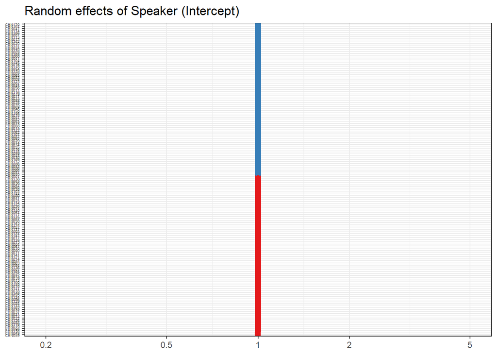

```r
p <- plot_model(mf, type = "re", sort.est = TRUE, grid = FALSE)
p[[1]] +
  theme_bw() +
  theme(axis.text.y = element_text(size=4))
```

```r
ggsave2(here::here("images", "re_spk.png"), width = 4, height = 12)
```

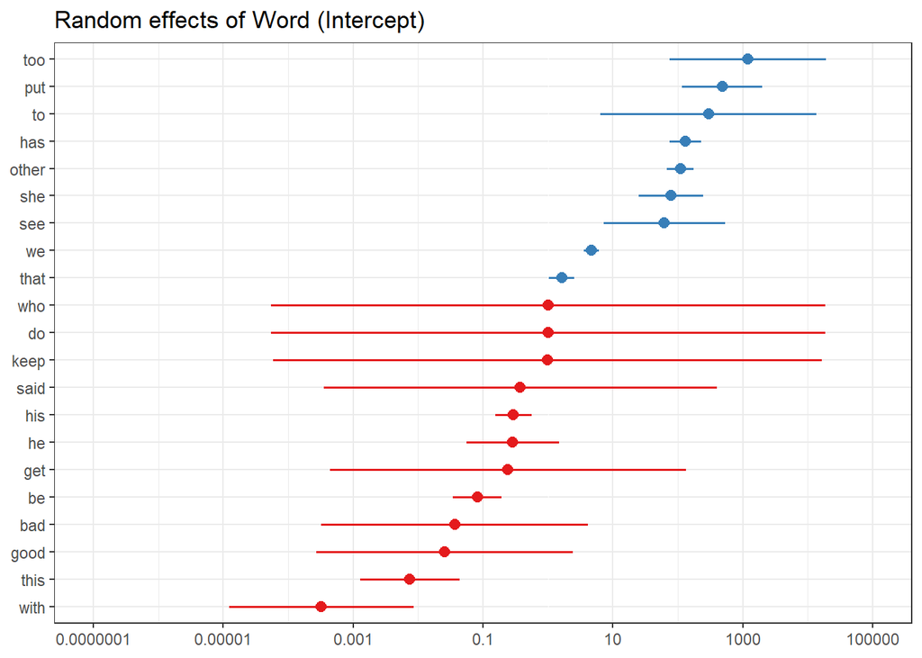

```r
p[[2]] +
  theme_bw()
```

```r
ggsave2(here::here("images", "re_wrds.png"), width = 6, height = 5)
```

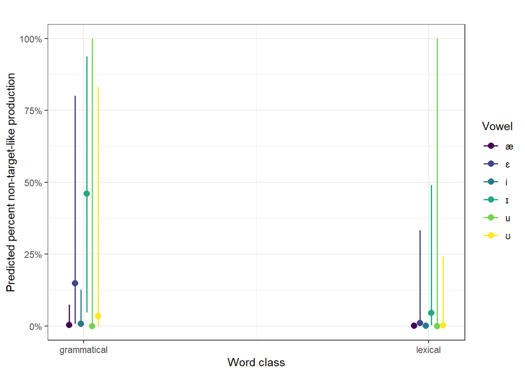

```r
sjPlot::plot_model(mf, type = "pred",
                   terms = c("WordClass", "Vowel"),
                   se = FALSE,
                   ci.lvl = FALSE,
                   colors = viridis(6)) +
  theme_bw() +
  labs(title = "", y = "Predicted percent non-target-like production",
       x = "Word class")
```

```r
ggsave2(here::here("images", "vowel_wc.png"), width = 5, height = 4)
```

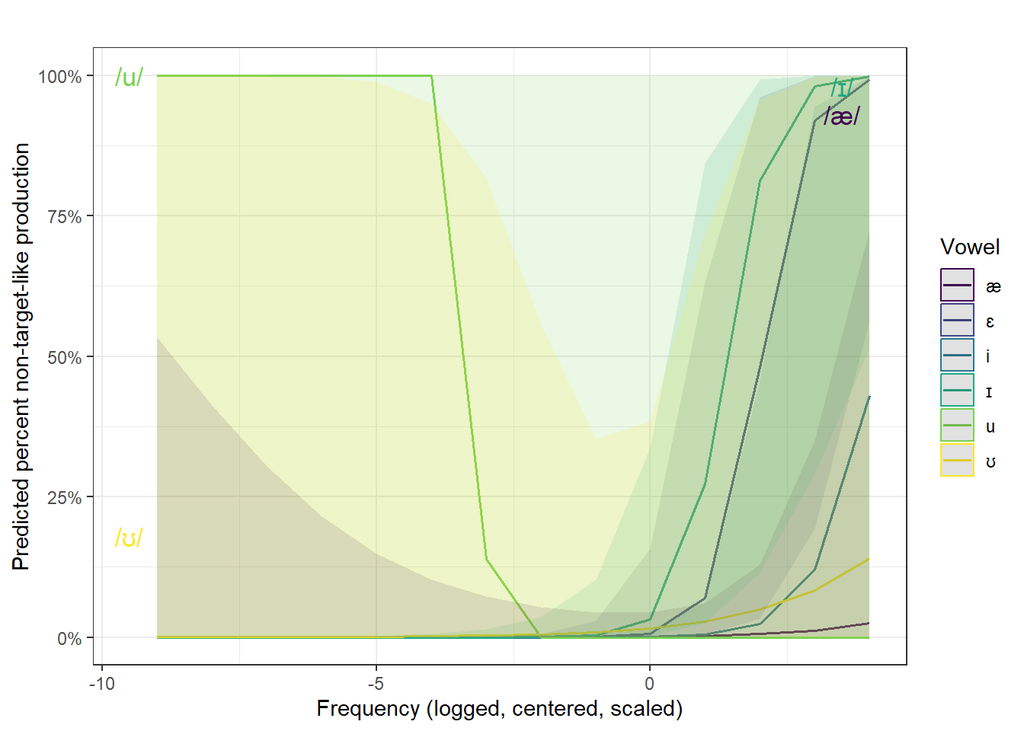

```r
sjPlot::plot_model(mf,
                   type = "pred",
                   terms = c("Frequency","Vowel"),
                   se = FALSE,
                   ci.lvl = FALSE,
                   colors = viridis(6)) +
  ggplot2::annotate(geom = "text", label = "/æ/", x = 3.5, y = .93, color = viridis(6)[1], size = 4.5) +
  ggplot2::annotate(geom = "text", label = "/ɪ/", x = 3.5, y = .98, color = viridis(6)[4], size = 4.5) +
  ggplot2::annotate(geom = "text", label = "/u/", x = -9.5, y = 1, color = viridis(6)[5], size = 4.5) +
  ggplot2::annotate(geom = "text", label = "/ʊ/", x = -9.5, y = .18, color = viridis(6)[6], size = 4.5) +
  theme_bw()  +
  labs(title = "", y = "Predicted percent non-target-like production",
       x = "Frequency (logged, centered, scaled)")
```

```r
ggsave2(here::here("images", "frequency.png"), width = 5, height = 4)
```

```r
p <- sjPlot::plot_model(mf,
                   type = "pred",
                   terms = c("Vowel"),
                   se = FALSE,
                   ci.lvl = FALSE)
mf_dat <- p$data$predicted %>%
  as.data.frame() %>%
  dplyr::mutate(Vowel = names(table(rdat$Vowel))) %>%
  dplyr::rename(Prediction = 1) %>%
  dplyr::mutate(Prediction = Prediction*100)
mf_dat
```

```
##                Prediction Vowel
## 1  0.35179949679836419740     æ
## 2 14.77759665616028783575     ɛ
## 3  0.78251484988273722898     i
## 4 46.04246894857135430357     ɪ
## 5  0.00000000000002220446     u
## 6  3.41154966106695933803     ʊ
```

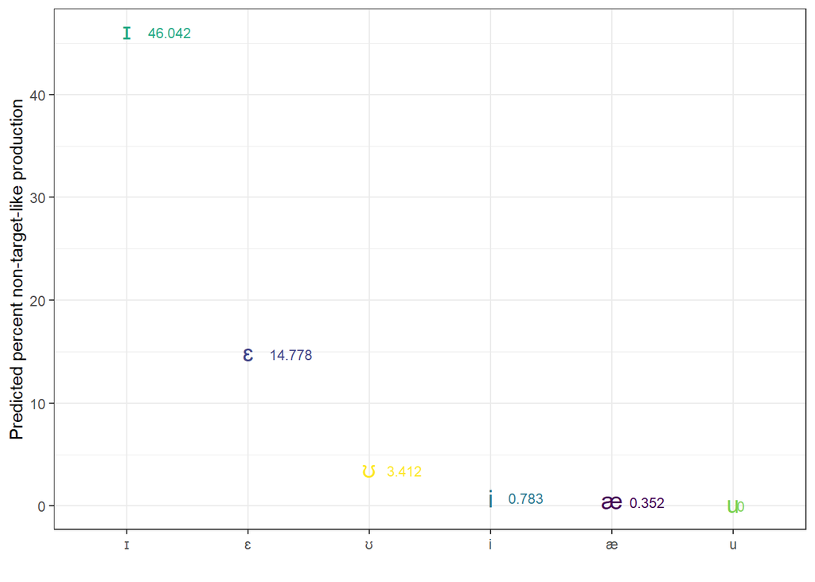

```r
mf_dat %>%
  ggplot(aes(x = reorder(Vowel, -Prediction, mean), y = Prediction, shape = Vowel, color = Vowel, label = round(Prediction, 3))) +
  geom_point(size = 5) +
  geom_text(size = 3, hjust=-0.5) +
  scale_shape_manual(values = names(table(mf_dat $Vowel))) +
  scale_color_manual(values = viridis(6)) +
  labs(y ="Predicted percent non-target-like production",
       x = "") +
  theme_bw() +
  theme(legend.position = "none")
```

```r
ggsave2(here::here("images", "vowel_vwl.png"), width = 5, height = 4)
```

# Tabulation

```r
# save tables
str(rdat)
```

```
## tibble [4,003 × 12] (S3: tbl_df/tbl/data.frame)
##  $ Word         : Factor w/ 21 levels "bad","be","do",..: 15 17 21 17 21 3 21 17 16 2 ...
##  $ F1           : num [1:4003] 2 1 0 0 0 0 1 0 2 0 ...
##  $ F2           : num [1:4003] 0 -1 -1 -2 -2 -1 1 -1 0 1 ...
##  $ Duration     : num [1:4003] 1.829 -0.297 0.193 -0.134 -0.625 ...
##  $ Vowel        : Factor w/ 6 levels "æ","ɛ","i","ɪ",..: 1 5 4 5 4 5 4 5 4 3 ...
##  $ Gender       : Factor w/ 2 levels "female","male": 2 2 2 2 2 2 2 2 2 1 ...
##  $ Age          : num [1:4003] -0.707 -0.707 -0.707 -0.707 -0.707 ...
##  $ WordClass    : Factor w/ 2 levels "grammatical",..: 1 1 1 1 1 1 1 1 1 1 ...
##  $ Frequency    : num [1:4003] 2.23 3.16 1.84 3.16 1.84 ...
##  $ NonNativeLike: Factor w/ 2 levels "0","1": 1 1 1 1 1 1 1 1 1 1 ...
##  $ Speaker      : Factor w/ 148 levels "CHN001","CHN002",..: 1 1 1 1 1 1 2 3 3 4 ...
##  $ Proficiency  : Factor w/ 3 levels "A2","B1","B2": 2 2 2 2 2 2 2 2 2 2 ...
```

```r
str(nsdtrain)
```

```
## tibble [2,459 × 9] (S3: tbl_df/tbl/data.frame)
##  $ Word     : chr [1:2459] "that" "be" "his" "be" ...
##  $ F1       : num [1:2459] 1.2026 -0.0696 -0.6407 -1.2286 1.0425 ...
##  $ F2       : num [1:2459] -0.881 2.533 1.098 1.179 1.048 ...
##  $ Duration : num [1:2459] 1.0107 -0.9516 0.0296 -0.461 -0.6245 ...
##  $ Vowel    : Factor w/ 6 levels "æ","ɛ","i","ɪ",..: 1 3 4 3 1 4 5 5 3 1 ...
##  $ Gender   : Factor w/ 2 levels "female","male": 2 2 2 1 2 1 2 2 2 1 ...
##  $ Age      : num [1:2459] -0.144 2.296 0.982 2.108 0.232 ...
##  $ WordClass: Factor w/ 2 levels "grammatical",..: 1 1 1 1 1 1 1 1 1 1 ...
##  $ Frequency: num [1:2459] 2.23 1.79 1.62 1.79 2.23 ...
```

```r
str(nsdtest)
```

```
## tibble [1,054 × 9] (S3: tbl_df/tbl/data.frame)
##  $ Word     : chr [1:1054] "get" "that" "with" "that" ...
##  $ F1       : num [1:1054] -0.203 0.599 0.377 0.899 1.252 ...
##  $ F2       : num [1:1054] 0.159 0.441 0.856 -0.668 -0.345 ...
##  $ Duration : num [1:1054] -1.115 -0.461 -0.297 -0.624 1.501 ...
##  $ Vowel    : Factor w/ 6 levels "æ","ɛ","i","ɪ",..: 2 1 4 1 1 4 1 1 5 1 ...
##  $ Gender   : Factor w/ 2 levels "female","male": 2 2 2 2 2 2 2 2 2 2 ...
##  $ Age      : num [1:1054] 1.92 1.92 1.92 1.92 1.92 ...
##  $ WordClass: Factor w/ 2 levels "grammatical",..: 1 1 1 1 1 1 1 1 1 1 ...
##  $ Frequency: num [1:1054] -0.441 2.233 1.843 2.233 2.233 ...
```

# Overview of the data

```r
tb1 <- bdat %>%
  dplyr::ungroup() %>%
  dplyr::group_by(type) %>%
  dplyr::mutate(speakers = length(table(Speaker))) %>%
  dplyr::ungroup() %>%
  dplyr::group_by(type, vowel) %>%
  dplyr::summarise(speakers = speakers,
                   obs = n()) %>%
  unique() %>%
  tidyr::spread(vowel, obs) %>%
  dplyr::ungroup()  %>%
  adorn_totals("row")%>%
  adorn_totals("col") %>%
  dplyr::mutate(Total = Total-speakers)
# save
write.table(tb1, here::here("tables", "tb1_uhh.txt"), sep = "\t")
# inspect
tb1
```

```
##   type speakers    æ   ɛ    i    ɪ    u   ʊ Total
##    CHN      148  576 263  847  858 1215 244  4003
##    ENS       87  872 340  662  446 1078 115  3513
##  Total      235 1448 603 1509 1304 2293 359  7516
```

tabulate proficiency

```r
tb3 <- bdat %>%
  dplyr::ungroup() %>%
  dplyr::filter(type == "CHN")%>%
  dplyr::group_by(Proficiency, Gender) %>%
  dplyr::summarise(speakers = length(table(Speaker))) %>%
  tidyr::spread(Proficiency, speakers) %>%
  dplyr::ungroup()  %>%
  adorn_totals("row")%>%
  adorn_totals("col")
# save
write.table(tb3, here::here("tables", "tb3_uhh.txt"), sep = "\t")
# inspect
tb3
```

```
##  Gender A2  B1 B2 Total
##  female  9  70  7    86
##    male  5  55  2    62
##   Total 14 125  9   148
```

tabulate gender and type

```r
tb4 <- bdat %>%
  dplyr::ungroup() %>%
  dplyr::group_by(Gender, type) %>%
  dplyr::summarise(speakers = length(table(Speaker))) %>%
  tidyr::spread(Gender, speakers) %>%
  dplyr::ungroup()  %>%
  adorn_totals("row")%>%
  adorn_totals("col")
# save
write.table(tb4, here::here("tables", "tb4_uhh.txt"), sep = "\t")
# inspect
tb4
```

```
##   type female male Total
##    CHN     86   62   148
##    ENS     30   57    87
##  Total    116  119   235
```

```r
summary(bdat)
```

```
##       id               Vowel               Word                 F1
##  Length:7516        Length:7516        Length:7516        Min.   :-3.0945
##  Class :character   Class :character   Class :character   1st Qu.:-0.7377
##  Mode  :character   Mode  :character   Mode  :character   Median :-0.1939
##                                                           Mean   : 0.0000
##                                                           3rd Qu.: 0.5008
##                                                           Max.   : 6.7835
##        F2              Duration         Speaker             vowel
##  Min.   :-2.80335   Min.   :-1.1151   Length:7516        Length:7516
##  1st Qu.:-0.63923   1st Qu.:-0.7880   Class :character   Class :character
##  Median :-0.06196   Median :-0.2975   Mode  :character   Mode  :character
##  Mean   : 0.00000   Mean   : 0.0000
##  3rd Qu.: 0.67740   3rd Qu.: 0.5202
##  Max.   : 3.83972   Max.   : 4.1181
##      type              Gender               Age              file
##  Length:7516        Length:7516        Min.   :-1.4575   Length:7516
##  Class :character   Class :character   1st Qu.:-0.7068   Class :character
##  Mode  :character   Mode  :character   Median :-0.3314   Mode  :character
##                                        Mean   : 0.0000
##                                        3rd Qu.: 0.4193
##                                        Max.   : 2.8591
##  TargetVariety          edist              barkF1            barkF2
##  Length:7516        Min.   :   2.664   Min.   :-0.1505   Min.   : 5.529
##  Class :character   1st Qu.: 240.999   1st Qu.: 3.6801   1st Qu.:10.151
##  Mode  :character   Median : 491.637   Median : 4.4703   Median :11.056
##                     Mean   : 557.990   Mean   : 4.6585   Mean   :11.003
##                     3rd Qu.: 839.164   3rd Qu.: 5.4029   3rd Qu.:12.076
##                     Max.   :2202.267   Max.   :11.2248   Max.   :15.240
##    fspeaker              lobF1.V1             lobF2.V1           normF1
##  Length:7516        Min.   :-2.981961   Min.   :-2.9112209   Min.   :   0.0
##  Class :character   1st Qu.:-0.645363   1st Qu.:-0.6547025   1st Qu.: 365.1
##  Mode  :character   Median :-0.356278   Median :-0.1020665   Median : 449.4
##                     Mean   :-0.130799   Mean   :-0.0418728   Mean   : 479.4
##                     3rd Qu.: 0.246467   3rd Qu.: 0.6034065   3rd Qu.: 557.0
##                     Max.   : 5.604566   Max.   : 2.9626529   Max.   :1530.3
##      normF2            cF1             cF2              ED
##  Min.   : 572.2   Min.   :4.090   Min.   :10.76   Min.   :0.01063
##  1st Qu.:1297.9   1st Qu.:4.204   1st Qu.:10.76   1st Qu.:0.81644
##  Median :1491.5   Median :4.204   Median :10.94   Median :1.22501
##  Mean   :1512.3   Mean   :4.743   Mean   :11.34   Mean   :1.44584
##  3rd Qu.:1739.5   3rd Qu.:5.046   3rd Qu.:11.48   3rd Qu.:1.76216
##  Max.   :2799.9   Max.   :5.960   Max.   :12.85   Max.   :7.32442
##    WordType         Proficiency  WordClass           Frequency
##  Length:7516        A2  : 429   Length:7516        Min.   :-8.0156
##  Class :character   B1  :3290   Class :character   1st Qu.: 0.6861
##  Mode  :character   B2  : 284   Mode  :character   Median : 1.7885
##                     NA's:3513                      Mean   : 1.4630
##                                                    3rd Qu.: 2.2328
##                                                    Max.   : 3.1610
##       freq
##  Min.   :  1.0
##  1st Qu.:170.0
##  Median :586.0
##  Mean   :493.8
##  3rd Qu.:816.0
##  Max.   :919.0
```

```r
summary(nnsd)
```

```
##      Word                 F1                F2              Duration
##  Length:4003        Min.   :-1.9854   Min.   :-2.80335   Min.   :-1.1151
##  Class :character   1st Qu.:-0.7991   1st Qu.:-0.66859   1st Qu.:-0.7880
##  Mode  :character   Median :-0.3435   Median :-0.12539   Median :-0.1339
##                     Mean   :-0.0873   Mean   :-0.07984   Mean   : 0.1927
##                     3rd Qu.: 0.3769   3rd Qu.: 0.62303   3rd Qu.: 0.8472
##                     Max.   : 6.7835   Max.   : 3.06225   Max.   : 4.1181
##     Vowel              Gender          Age                WordClass
##  Length:4003        female:2720   Min.   :-1.4575   grammatical:3498
##  Class :character   male  :1283   1st Qu.:-0.8945   lexical    : 505
##  Mode  :character                 Median :-0.7068
##                                   Mean   :-0.5825
##                                   3rd Qu.:-0.5191
##                                   Max.   : 1.3577
##    Frequency       NativeChoice       NonNativeLike
##  Min.   :-8.0156   Length:4003        Min.   :0.0000
##  1st Qu.: 0.6861   Class :character   1st Qu.:0.0000
##  Median : 1.6869   Mode  :character   Median :0.0000
##  Mean   : 1.3347                      Mean   :0.0707
##  3rd Qu.: 2.2328                      3rd Qu.:0.0000
##  Max.   : 3.1610                      Max.   :1.0000
```

```r
summary(rdat)
```

```
##       Word            F1                F2              Duration       Vowel
##  to     : 919   Min.   :-2.0000   Min.   :-3.00000   Min.   :-1.1150   æ: 576
##  we     : 650   1st Qu.:-1.0000   1st Qu.:-1.00000   1st Qu.:-0.7880   ɛ: 263
##  that   : 412   Median : 0.0000   Median : 0.00000   Median :-0.1340   i: 847
##  with   : 337   Mean   :-0.1172   Mean   :-0.08144   Mean   : 0.1927   ɪ: 858
##  be     : 292   3rd Qu.: 0.0000   3rd Qu.: 1.00000   3rd Qu.: 0.8470   u:1215
##  this   : 234   Max.   : 7.0000   Max.   : 3.00000   Max.   : 4.1180   ʊ: 244
##  (Other):1159
##     Gender          Age                WordClass      Frequency
##  female:2720   Min.   :-1.4575   grammatical:3498   Min.   :-8.0156
##  male  :1283   1st Qu.:-0.8945   lexical    : 505   1st Qu.: 0.6861
##                Median :-0.7068                      Median : 1.6869
##                Mean   :-0.5825                      Mean   : 1.3347
##                3rd Qu.:-0.5191                      3rd Qu.: 2.2328
##                Max.   : 1.3577                      Max.   : 3.1610
##
##  NonNativeLike    Speaker     Proficiency
##  0:3720        CHN098 :  68   A2: 429
##  1: 283        CHN121 :  59   B1:3290
##                CHN119 :  54   B2: 284
##                CHN079 :  50
##                CHN120 :  47
##                CHN097 :  46
##                (Other):3679
```

# Outro

```r
# save tables
base::saveRDS(rdat, file = here::here("tables", "rdat.rda"))
base::saveRDS(nsdtrain, file = here::here("tables", "nsdtrain.rda"))
base::saveRDS(nsdtest, file = here::here("tables", "nsdtest.rda"))
```

# Citation & Session Info

Schweinberger, Martin. 2023. Pushing the boundaries - analysing English vowel production among Chinese learners of English - Part 3: Statistical Analysis.